# DigitecGalaxus Retail Operations: Empirical Analysis

Vithushanan Manoharan

5 August 2026

```r
required_packages <- c(
  "tidyverse", "readr", "janitor", "lubridate", "fixest",
  "modelsummary", "broom", "glue", "scales", "knitr", "gridExtra"
)

missing_packages <- required_packages[
  !vapply(required_packages, requireNamespace, logical(1), quietly = TRUE)
]

if (length(missing_packages) > 0) {
  stop(
    paste(
      "Install the following packages before rendering:",
      paste(missing_packages, collapse = ", ")
    ),
    call. = FALSE
  )
}

library(tidyverse)
library(readr)
library(janitor)
library(lubridate)
library(fixest)
library(modelsummary)
library(broom)
library(glue)
library(scales)
library(knitr)
library(grid)
library(gridExtra)
```

```r
options(scipen = 999)
theme_set(theme_minimal())

knitr::opts_chunk$set(
  echo = TRUE,
  message = FALSE,
  warning = FALSE,
  fig.align = "center",
  fig.width = 10,
  fig.height = 5.5,
  out.width = "100%"
)

# Descriptive plots trim the outer 1% only; all models use the full panel.
trim_plot_outliers <- TRUE
plot_quantile_low <- 0.01
plot_quantile_high <- 0.99

# Set THESIS_DATA_DIR when the data are stored outside this project folder.
data_dir <- Sys.getenv("THESIS_DATA_DIR", unset = getwd())

output_dir <- file.path(data_dir, "output")
dir.create(output_dir, showWarnings = FALSE)
dir.create(file.path(output_dir, "clean_data"), showWarnings = FALSE, recursive = TRUE)
dir.create(file.path(output_dir, "tables"), showWarnings = FALSE, recursive = TRUE)
dir.create(file.path(output_dir, "figures"), showWarnings = FALSE, recursive = TRUE)
dir.create(file.path(output_dir, "tables_png"), showWarnings = FALSE, recursive = TRUE)
dir.create(file.path(output_dir, "figures_png"), showWarnings = FALSE, recursive = TRUE)
dir.create(file.path(output_dir, "appendix_png"), showWarnings = FALSE, recursive = TRUE)
dir.create(file.path(output_dir, "diagnostics"), showWarnings = FALSE, recursive = TRUE)

kpi_file <- file.path(data_dir, "202604_RetailAbfrageVithuRetailKPI_DT_ZH.csv")
tickets_file_total <- file.path(data_dir, "202604_RetailAbfrageTicketsVithu.csv")
tickets_file_dt <- file.path(data_dir, "202604_RetailAbfrageTicketsVithu_DT.csv")
tickets_file_zh <- file.path(data_dir, "202604_RetailAbfrageTicketsVithu_ZH.csv")
nps_file_dt <- file.path(data_dir, "NPS_DT.csv")
nps_file_zh <- file.path(data_dir, "NPS_ZH.csv")
productivity_file <- file.path(data_dir, "productivity_monthly_analysis_dt_zh_v2.csv")

fee_date <- as.Date("2024-10-01")
steg_date <- as.Date("2023-09-08")
melectronics_date <- as.Date("2024-11-30")
same_day_end_date <- as.Date("2025-09-29")

analysis_start <- as.Date("2018-01-01")
analysis_end <- as.Date("2025-12-31")
```

> **Supplementary code report.** The source code is shown in full. The confidential input data are not embedded in this file.

# 1 Purpose of the Empirical Script

This report contains the code used to prepare the empirical results for the thesis. It builds the weekly Dietikon–Zurich panel, reports descriptive period comparisons, estimates the fixed-effects and event-based models, examines store heterogeneity, and analyses monthly productivity and NPS separately.

The code checks the input files and key variables before estimation. Duplicate store-week records, missing values, zero values, and models that cannot be estimated are documented in the diagnostics folder. The combined ticket file without store identifiers is retained only as a network-level reference and is not merged into the store-level panel.

The report also exports the tables and figures used in the thesis. Figures are written to `output/figures_png`, tables to `output/tables_png`, and appendix-ready copies to `output/appendix_png`.

```r
model_log <- tibble(
  model_group = character(),
  outcome = character(),
  transform = character(),
  status = character(),
  reason = character()
)

log_model_status <- function(model_group, outcome, transform, status, reason = "") {
  model_log <<- bind_rows(
    model_log,
    tibble(
      model_group = model_group,
      outcome = outcome,
      transform = transform,
      status = status,
      reason = reason
    )
  )
}

require_file <- function(path) {
  if (!file.exists(path)) {
    stop(glue("File not found: {path}"), call. = FALSE)
  }
  invisible(TRUE)
}

require_cols <- function(data, cols, data_name = "data") {
  missing_cols <- setdiff(cols, names(data))
  if (length(missing_cols) > 0) {
    stop(glue("{data_name} is missing required columns: {paste(missing_cols, collapse = ', ')}"), call. = FALSE)
  }
  invisible(TRUE)
}

parse_numeric <- function(x) {
  if (is.numeric(x)) return(x)
  x %>%
    as.character() %>%
    str_replace_all("'", "") %>%
    str_replace_all("%", "") %>%
    str_replace_all(",", ".") %>%
    na_if("") %>%
    as.numeric()
}

safe_log <- function(x) {
  # Non-positive values cannot enter the log specification.
  if_else(!is.na(x) & is.finite(x) & x > 0, log(x), NA_real_)
}

safe_log1p <- function(x) {
  # log1p retains zero values; negative values are excluded.
  if_else(!is.na(x) & is.finite(x) & x >= 0, log1p(x), NA_real_)
}

parse_week_date <- function(x) {
  suppressWarnings(dmy(as.character(x)))
}

parse_nps_month <- function(x) {
  # Normalise the month labels used in the NPS export.
  x_clean <- as.character(x) %>%
    str_replace_all("\\.", "") %>%
    str_replace("^Sept", "Sep")
  suppressWarnings(parse_date_time(paste("01", x_clean), orders = c("d b y", "d B y"))) %>%
    as.Date() %>%
    floor_date("month")
}

check_unique_key <- function(data, key_cols, data_name = "data") {
  dup <- data %>%
    count(across(all_of(key_cols)), name = "n") %>%
    filter(n > 1)
  if (nrow(dup) > 0) {
    write_csv(dup, file.path(output_dir, "diagnostics", paste0(data_name, "_duplicate_keys.csv")))
    stop(glue("Duplicate keys found in {data_name}. See diagnostics/{data_name}_duplicate_keys.csv"), call. = FALSE)
  }
  invisible(TRUE)
}

make_data_quality_report <- function(data, id_cols = c("store", "week_start"), data_name = "weekly_panel") {
  numeric_cols <- names(data)[map_lgl(data, is.numeric)]
  report <- tibble(variable = numeric_cols) %>%
    mutate(
      n_total = nrow(data),
      n_missing = map_int(variable, ~ sum(is.na(data[[.x]]))),
      share_missing = n_missing / n_total,
      n_zero = map_int(variable, ~ sum(data[[.x]] == 0, na.rm = TRUE)),
      n_negative = map_int(variable, ~ sum(data[[.x]] < 0, na.rm = TRUE)),
      n_nonfinite = map_int(variable, ~ sum(!is.finite(data[[.x]]) & !is.na(data[[.x]]))),
      n_distinct = map_int(variable, ~ n_distinct(data[[.x]], na.rm = TRUE)),
      min = map_dbl(variable, ~ suppressWarnings(min(data[[.x]], na.rm = TRUE))),
      max = map_dbl(variable, ~ suppressWarnings(max(data[[.x]], na.rm = TRUE))),
      mean = map_dbl(variable, ~ suppressWarnings(mean(data[[.x]], na.rm = TRUE)))
    ) %>%
    mutate(
      min = if_else(is.infinite(min), NA_real_, min),
      max = if_else(is.infinite(max), NA_real_, max),
      mean = if_else(is.nan(mean), NA_real_, mean)
    ) %>%
    arrange(desc(share_missing), desc(n_zero))

  write_csv(report, file.path(output_dir, "diagnostics", paste0(data_name, "_quality_report.csv")))
  report
}

add_log_variables <- function(data) {
  numeric_cols <- names(data)[map_lgl(data, is.numeric)]
  numeric_cols <- setdiff(numeric_cols, c("year", "month", "week_number", "week_of_year", "time_index",
                                         "covid", "postcovid", "newnormal",
                                         "fee_post", "steg_post", "melectronics_post", "competitor_post", "same_day_end_post"))
  data %>%
    mutate(across(all_of(numeric_cols), safe_log, .names = "ln_{.col}")) %>%
    mutate(across(all_of(numeric_cols), safe_log1p, .names = "ln1p_{.col}"))
}

has_usable_variation <- function(data, var) {
  if (!var %in% names(data)) return(FALSE)
  x <- data[[var]]
  x <- x[!is.na(x) & is.finite(x)]
  length(x) >= 20 && n_distinct(x) > 1
}

available_vars <- function(vars, data) {
  vars[vars %in% names(data)]
}

# Labels used in tables and figures.
coef_label_map <- c(
  "covid" = "COVID (2020--2021)",
  "postcovid" = "Post-COVID (2022--2023)",
  "newnormal" = "New Normal (2024--2025)",
  "fee_post" = "After CHF 4.90 fee",
  "steg_post" = "After STEG exit",
  "melectronics_post" = "After melectronics exit",
  "competitor_post" = "After competitor exit",
  "same_day_end_post" = "After same-day delivery cancellation",
  "clean_post" = "Post-event (clean window)",
  "event_time" = "Weekly event-time trend",
  "ln_tickets_abholung" = "Log collection tickets",
  "ln_tickets_beratung" = "Log consultation tickets",
  "ln_total_tickets" = "Log total tickets",
  "ln_throughput_proxy" = "Log Turnover per ticket",
  "ln_avg_waiting_time_beratung" = "Log consultation waiting time",
  "consultation_share" = "Consultation share",
  "storeZH" = "Zurich store",
  "fee_post:storeZH" = "Fee event x Zurich",
  "same_day_end_post:storeZH" = "Same-day cancellation x Zurich"
)

model_label_map <- c(
  "total_turnover" = "Total turnover",
  "direct_turnover" = "Direct turnover",
  "direct_turnover_all" = "Direct turnover",
  "direct_turnover_relevant" = "Direct turnover, relevant",
  "turnover_ordered_collection" = "Ordered for collection",
  "turnover_added_collection" = "Added for collection",
  "collection_turnover" = "Collection turnover",
  "turnover_collected" = "Turnover collected",
  "deliveries_collected" = "Deliveries collected",
  "turnover_per_ticket" = "Turnover per ticket",
  "throughput_proxy" = "Turnover per ticket",
  "productivity" = "Productivity",
  "total_tickets" = "Total tickets",
  "tickets_abholung" = "Collection tickets",
  "tickets_beratung" = "Consultation tickets",
  "avg_waiting_time_abholung" = "Collection waiting time",
  "avg_waiting_time_beratung" = "Consultation waiting time",
  "median_waiting_time_abholung" = "Median collection waiting time",
  "median_waiting_time_beratung" = "Median consultation waiting time",
  "avg_duration_abholung" = "Collection duration",
  "avg_duration_beratung" = "Consultation duration",
  "median_duration_abholung" = "Median collection duration",
  "median_duration_beratung" = "Median consultation duration",
  "consultation_ratio" = "Consultation ratio",
  "consultation_share" = "Consultation share",
  "collection_workload" = "Collection workload",
  "consultation_workload" = "Consultation workload",
  "workload_proxy" = "Workload proxy",
  "nps_score" = "NPS score",
  "turnover_ordered_shipment" = "Ordered for shipment",
  "turnover_added_shipment" = "Added for shipment",
  "shipment_turnover" = "Shipment turnover"
)
```

```r
rename_models_for_thesis <- function(models) {
  models <- purrr::compact(models)
  if (length(models) == 0) return(models)
  old_names <- names(models)
  new_names <- if_else(
    old_names %in% names(model_label_map),
    unname(model_label_map[old_names]),
    old_names
  )
  names(models) <- new_names
  models
}

select_model_subset <- function(models, wanted) {
  models <- purrr::compact(models)
  models[intersect(wanted, names(models))]
}

star_levels <- c("*" = 0.05, "**" = 0.01, "***" = 0.001)
significance_note <- "Significance levels: *** p < 0.001, ** p < 0.01, * p < 0.05."

# Format p-values for presentation without changing the underlying estimates.
# A displayed value of 0.000 is only a rounding artefact; very small positive
# p-values are conventionally reported as <0.001.
format_p_value <- function(x, digits = 3) {
  threshold <- 10^(-digits)

  case_when(
    is.na(x) ~ "",
    x < threshold ~ paste0("<", formatC(
      threshold,
      format = "f",
      digits = digits,
      decimal.mark = "."
    )),
    TRUE ~ formatC(
      x,
      format = "f",
      digits = digits,
      decimal.mark = "."
    )
  )
}

default_table_notes <- c(
  "Heteroskedasticity-robust standard errors in parentheses.",
  "Weekly models include store and week-of-year fixed effects unless stated otherwise.",
  "Dependent variables are log-transformed unless the table states otherwise.",
  significance_note
)

clean_period_label <- function(x) {
  x %>%
    as.character() %>%
    str_replace_all("Pre-COVID", "Pre COVID") %>%
    str_replace_all("Post-COVID", "Post COVID")
}

compact_gof_map <- tibble::tribble(
  ~raw, ~clean, ~fmt,
  "nobs", "Observations", 0,
  "r.squared", "R2", 3,
  "r2.within", "Within R2", 3
)

appendix_png_path <- function(filename) {
  file.path(output_dir, "appendix_png", filename)
}

table_png_path <- function(filename) {
  file.path(output_dir, "tables_png", filename)
}

figure_png_path <- function(filename) {
  file.path(output_dir, "figures_png", filename)
}

write_png_table <- function(df, filename, title = NULL, note = NULL,
                            digits = 2, subdir = "tables_png",
                            base_width = 1800, row_height = 42,
                            font_size = 9, title_size = 13,
                            note_size = 8) {
  # Render tables directly with gridExtra.

  if (!str_detect(filename, "\\.png$")) {
    filename <- paste0(filename, ".png")
  }

  png_file <- file.path(output_dir, subdir, filename)

  df_display <- df %>%
    as.data.frame(check.names = FALSE) %>%
    mutate(across(where(is.factor), as.character)) %>%
    mutate(across(where(is.Date), as.character))

  # Format numeric columns before drawing the table.
  numeric_cols <- names(df_display)[map_lgl(df_display, is.numeric)]
  if (length(numeric_cols) > 0) {
    df_display <- df_display %>%
      mutate(across(
        all_of(numeric_cols),
        ~ ifelse(
          is.na(.x),
          "",
          formatC(.x, format = "f", digits = digits, big.mark = "'", decimal.mark = ".")
        )
      ))
  }

  df_display <- df_display %>%
    mutate(across(everything(), ~ ifelse(is.na(.x), "", as.character(.x))))

  # Adapt the image size to the number of rows and columns.
  n_cols <- max(1, ncol(df_display))
  n_rows <- max(1, nrow(df_display))
  dynamic_font_size <- ifelse(n_cols >= 8, max(6, font_size - 2), font_size)
  dynamic_width <- max(base_width, n_cols * 230)
  dynamic_height <- max(700, (n_rows + 2) * row_height + 180)

  table_theme <- gridExtra::ttheme_minimal(
    base_size = dynamic_font_size,
    core = list(
      fg_params = list(hjust = 0, x = 0.03),
      padding = unit(c(4, 4), "mm")
    ),
    colhead = list(
      fg_params = list(fontface = "bold", hjust = 0, x = 0.03),
      padding = unit(c(4, 4), "mm")
    )
  )

  table_grob <- gridExtra::tableGrob(df_display, rows = NULL, theme = table_theme)

  top_grob <- if (!is.null(title)) {
    grid::textGrob(
      title,
      x = 0,
      hjust = 0,
      gp = grid::gpar(fontsize = title_size, fontface = "bold")
    )
  } else {
    NULL
  }

  bottom_grob <- if (!is.null(note)) {
    grid::textGrob(
      note,
      x = 0,
      hjust = 0,
      gp = grid::gpar(fontsize = note_size)
    )
  } else {
    NULL
  }

  combined <- gridExtra::arrangeGrob(
    table_grob,
    top = top_grob,
    bottom = bottom_grob,
    padding = unit(0.6, "line")
  )

  grDevices::png(
    filename = png_file,
    width = dynamic_width,
    height = dynamic_height,
    res = 160,
    bg = "white"
  )
  grid::grid.newpage()
  grid::grid.draw(combined)
  grDevices::dev.off()

  # Keep an appendix-ready copy.
  if (file.exists(png_file) && subdir != "appendix_png") {
    file.copy(png_file, appendix_png_path(filename), overwrite = TRUE)
  }

  invisible(png_file)
}

save_df_table_png <- function(df, filename, title = NULL, note = NULL, digits = 2,
                              vwidth = 1600, vheight = 1000) {
  # vheight is retained for compatibility with earlier calls.
  write_png_table(
    df = df,
    filename = filename,
    title = title,
    note = note,
    digits = digits,
    subdir = "tables_png",
    base_width = vwidth
  )
}

save_plot_png <- function(plot_obj, filename, width = 10, height = 5.5, dpi = 300) {
  # Save the working copy and an appendix-ready copy.
  if (is.null(plot_obj)) return(invisible(NULL))
  if (!str_detect(filename, "\\.png$")) {
    filename <- paste0(filename, ".png")
  }

  ggsave(
    filename = figure_png_path(filename),
    plot = plot_obj,
    width = width,
    height = height,
    dpi = dpi,
    units = "in",
    bg = "white"
  )
  file.copy(figure_png_path(filename), appendix_png_path(filename), overwrite = TRUE)
  invisible(figure_png_path(filename))
}

save_model_table <- function(models, filename, title = NULL, notes = default_table_notes) {
  models <- purrr::compact(models)
  if (length(models) == 0) return(invisible(NULL))

  models_pretty <- rename_models_for_thesis(models)
  filename_stub <- tools::file_path_sans_ext(basename(filename))
```

```r
  # Editable LaTeX table version.
  modelsummary(
    models_pretty,
    output = file.path(output_dir, "tables", paste0(filename_stub, ".tex")),
    stars = star_levels,
    estimate = "{estimate}{stars}",
    statistic = "({std.error})",
    coef_map = coef_label_map,
    title = title,
    notes = notes,
    gof_map = compact_gof_map,
    fmt = 3
  )

  # HTML version for checking the output.
  modelsummary(
    models_pretty,
    output = file.path(output_dir, "tables", paste0(filename_stub, ".html")),
    stars = star_levels,
    estimate = "{estimate}{stars}",
    statistic = "({std.error})",
    coef_map = coef_label_map,
    title = title,
    notes = notes,
    gof_map = compact_gof_map,
    fmt = 3
  )

  # PNG version used in the appendix.
  model_df <- modelsummary(
    models_pretty,
    output = "data.frame",
    stars = star_levels,
    estimate = "{estimate}{stars}",
    statistic = "({std.error})",
    coef_map = coef_label_map,
    gof_map = compact_gof_map,
    fmt = 3
  ) %>%
    as.data.frame(check.names = FALSE)

  # Prepare the modelsummary data frame for image rendering.
  # The `statistic` column is internal modelsummary metadata. Keeping it in
  # the PNG table would print the template label `({std.error})` beside every
  # standard-error row. Explicitly blank the term cell on those rows and then
  # remove the metadata column. The numerical standard errors remain in
  # parentheses in the model columns.
  if (all(c("term", "statistic") %in% names(model_df))) {
    standard_error_row <- str_detect(
      as.character(model_df$statistic),
      "std\\.error"
    )
    standard_error_row[is.na(standard_error_row)] <- FALSE
    model_df$term[standard_error_row] <- ""
  }

  model_df <- model_df %>%
    select(-any_of(c("part", "statistic")))

  names(model_df) <- names(model_df) %>%
    str_replace("^term$", "Term")

  table_note <- paste(notes, collapse = " ")

  write_png_table(
    df = model_df,
    filename = paste0(filename_stub, ".png"),
    title = title,
    note = table_note,
    digits = 3,
    subdir = "tables_png",
    base_width = 2200,
    row_height = 40,
    font_size = 8,
    title_size = 13,
    note_size = 8
  )

  invisible(NULL)
}

display_model_table <- function(models, title = NULL, notes = default_table_notes) {
  models <- purrr::compact(models)
  if (length(models) == 0) {
    cat("\\textit{No models are displayed because the relevant variables or event dates are not available. See the model log in the diagnostics folder.}\n\n")
    return(invisible(NULL))
  }

  modelsummary(
    rename_models_for_thesis(models),
    stars = star_levels,
    estimate = "{estimate}{stars}",
    statistic = "({std.error})",
    coef_map = coef_label_map,
    title = title,
    notes = notes,
    gof_map = compact_gof_map,
    fmt = 3
  )
}

plot_event_coefficients <- function(models, title, filename) {
  models <- purrr::compact(models)
  if (length(models) == 0) {
    cat("\\textit{No coefficient plot is displayed because no event models were estimated.}\n\n")
    return(invisible(NULL))
  }

  coef_df <- imap_dfr(models, function(model, outcome_name) {
    broom::tidy(model, conf.int = TRUE) %>%
      filter(!str_detect(term, "Intercept")) %>%
      mutate(
        outcome = if_else(
          outcome_name %in% names(model_label_map),
          unname(model_label_map[outcome_name]),
          outcome_name
        ),
        term_label = if_else(
          term %in% names(coef_label_map),
          unname(coef_label_map[term]),
          term
        )
      )
  })

  if (nrow(coef_df) == 0) {
    cat("\\textit{No event coefficients are available for plotting.}\n\n")
    return(invisible(NULL))
  }

  p <- ggplot(coef_df, aes(x = estimate, y = reorder(outcome, estimate))) +
    geom_vline(xintercept = 0, linetype = "dashed") +
    geom_errorbarh(aes(xmin = conf.low, xmax = conf.high), height = 0.18) +
    geom_point(size = 2) +
    facet_wrap(~ term_label, scales = "free_x") +
    labs(
      title = title,
      subtitle = "Whiskers show 95% confidence intervals; regression tables report significance stars.",
      x = "Estimated coefficient with 95% confidence interval",
      y = NULL
    )

  print(p)
  ggsave(file.path(output_dir, "figures", filename), p, width = 9, height = 5, bg = "white")
  save_plot_png(p, filename, width = 9, height = 5)
  invisible(p)
}

run_fe_model <- function(data, outcome, rhs, model_group, transform = c("level", "log", "log1p"),
                         fixed_effects = "store + week_of_year_fe",
                         min_n = 30) {
  transform <- match.arg(transform)

  y <- case_when(
    transform == "level" ~ outcome,
    transform == "log" ~ paste0("ln_", outcome),
    transform == "log1p" ~ paste0("ln1p_", outcome)
  )

  if (!y %in% names(data)) {
    log_model_status(model_group, outcome, transform, "skipped", glue("Outcome variable {y} not found."))
    return(NULL)
  }

  rhs_vars <- all.vars(as.formula(paste("~", rhs)))
  missing_rhs <- setdiff(rhs_vars, names(data))
  if (length(missing_rhs) > 0) {
    log_model_status(model_group, outcome, transform, "skipped", glue("Missing RHS variable(s): {paste(missing_rhs, collapse = ', ')}"))
    return(NULL)
  }

  required_for_model <- unique(c(y, rhs_vars, all.vars(as.formula(paste("~", fixed_effects)))))
  model_data <- data %>%
    select(all_of(required_for_model)) %>%
    drop_na()

  if (nrow(model_data) < min_n) {
    log_model_status(model_group, outcome, transform, "skipped", glue("Too few complete observations: {nrow(model_data)}."))
    return(NULL)
  }

  if (n_distinct(model_data[[y]]) <= 1) {
    log_model_status(model_group, outcome, transform, "skipped", "Outcome has no usable variation after filtering.")
    return(NULL)
  }

  rhs_no_functions <- rhs_vars
  no_variation_rhs <- rhs_no_functions[map_lgl(rhs_no_functions, ~ n_distinct(model_data[[.x]]) <= 1)]
  if (length(no_variation_rhs) > 0) {
    log_model_status(model_group, outcome, transform, "skipped", glue("RHS variable(s) have no variation: {paste(no_variation_rhs, collapse = ', ')}"))
    return(NULL)
  }
```

```r
  fml <- as.formula(glue("{y} ~ {rhs} | {fixed_effects}"))

  fit <- tryCatch(
    feols(fml, data = data, vcov = "hetero", notes = FALSE),
    error = function(e) e
  )

  if (inherits(fit, "error")) {
    log_model_status(model_group, outcome, transform, "error", fit$message)
    return(NULL)
  }

  log_model_status(model_group, outcome, transform, "estimated", "")
  fit
}

event_week_start <- function(event_date) {
  # Convert event dates to the Monday of the corresponding week.

  x <- event_date
  if (!inherits(x, "Date")) {
    x <- as.Date(x)
  }
  as.Date(floor_date(x, unit = "week", week_start = 1))
}

make_post_dummy <- function(date_var, event_date) {
  if (length(event_date) == 0 || is.na(event_date)) return(rep(NA_integer_, length(date_var)))
  as.integer(date_var >= event_week_start(event_date))
}

plot_weekly_series <- function(data, y_var, title, y_label = NULL,
                               trim_outliers = trim_plot_outliers,
                               q_low = plot_quantile_low,
                               q_high = plot_quantile_high) {
  if (!y_var %in% names(data)) return(NULL)

  plot_data <- data %>%
    filter(!is.na(.data[[y_var]]), is.finite(.data[[y_var]]))

  subtitle_text <- "Descriptive plot; model estimates use the full untrimmed sample."

  if (trim_outliers && nrow(plot_data) > 0) {
    qs <- quantile(plot_data[[y_var]], probs = c(q_low, q_high), na.rm = TRUE, names = FALSE)

    if (length(qs) == 2 && all(is.finite(qs)) && qs[1] < qs[2]) {
      outlier_rows <- plot_data %>%
        filter(.data[[y_var]] < qs[1] | .data[[y_var]] > qs[2]) %>%
        select(store, week_start, all_of(y_var))

      if (nrow(outlier_rows) > 0) {
        write_csv(
          outlier_rows,
          file.path(output_dir, "diagnostics", paste0("plot_outliers_removed_", y_var, ".csv"))
        )
      }

      plot_data <- plot_data %>%
        filter(.data[[y_var]] >= qs[1], .data[[y_var]] <= qs[2])

      subtitle_text <- glue(
        "Displayed after trimming values below p{100*q_low} and above p{100*q_high}; regressions use the full untrimmed sample."
      )
    }
  }

  ggplot(plot_data, aes(x = week_start, y = .data[[y_var]], colour = store)) +
    geom_line(alpha = 0.65, na.rm = TRUE) +
    geom_smooth(se = FALSE, linewidth = 0.75, na.rm = TRUE) +
    scale_y_continuous(labels = comma) +
    labs(
      title = title,
      subtitle = subtitle_text,
      x = NULL,
      y = y_label %||% y_var,
      colour = "Store"
    )
}
```

# 2 Data Construction and Diagnostics

The empirical panel is constructed from internal KPI, ticketing and NPS exports. Raw diagnostics are written to the diagnostics folder, while this report displays only the compact checks needed to document the data structure used for the thesis analysis.

```r
require_file(kpi_file)

kpi_raw <- read_csv(kpi_file, show_col_types = FALSE) %>%
  clean_names()

require_cols(kpi_raw, c("site_id", "name", "value", "date", "site_abbreviation", "week", "year"), "KPI data")

glimpse(kpi_raw)

kpi_name_map <- c(
  "Total turnover generated in Retail" = "total_turnover",
  "Direct Turnover (All product types)" = "direct_turnover_all",
  "Direct Turnover (only relevant product types)" = "direct_turnover_relevant",
  "Turnover - Ordered in Retail for collection" = "turnover_ordered_collection",
  "Turnover - Added in Retail for collection" = "turnover_added_collection",
  "Turnover - Ordered in Retail for shipment" = "turnover_ordered_shipment",
  "Turnover - Added in Retail for shipment" = "turnover_added_shipment",
  "Turnover Collected" = "turnover_collected",
  "Deliveries collected" = "deliveries_collected",
  "Number of tickets created" = "tickets_created_kpi",
  "Turnover generated per ticket created" = "turnover_per_ticket",
  "Productivity" = "productivity"
)

kpi_name_audit <- kpi_raw %>%
  count(name, sort = TRUE)

write_csv(kpi_name_audit, file.path(output_dir, "diagnostics", "kpi_raw_name_audit.csv"))
kpi_name_audit

# Sum flow variables within each store-week and average ratio variables.

ratio_kpis <- c("turnover_per_ticket", "productivity")

kpi_weekly <- kpi_raw %>%
  mutate(
    store = as.character(site_abbreviation),
    date = dmy(date),
    value = parse_numeric(value),
    kpi = recode(name, !!!kpi_name_map, .default = NA_character_),
    week_start = floor_date(date, unit = "week", week_start = 1)
  ) %>%
  filter(store %in% c("DT", "ZH")) %>%
  filter(!is.na(kpi)) %>%
  filter(date >= analysis_start, date <= analysis_end) %>%
  group_by(store, week_start, kpi) %>%
  summarise(
    value = if_else(first(kpi) %in% ratio_kpis,
                    mean(value, na.rm = TRUE),
                    sum(value, na.rm = TRUE)),
    .groups = "drop"
  ) %>%
  pivot_wider(names_from = kpi, values_from = value) %>%
  arrange(store, week_start) %>%
  mutate(
    year = year(week_start),
    month = month(week_start),
    week_of_year = isoweek(week_start),
    month_start = floor_date(week_start, "month"),
    direct_turnover = coalesce(direct_turnover_all, direct_turnover_relevant),
    collection_turnover = coalesce(turnover_ordered_collection, 0) + coalesce(turnover_added_collection, 0),
    shipment_turnover = coalesce(turnover_ordered_shipment, 0) + coalesce(turnover_added_shipment, 0),
    collection_share_turnover = if_else(total_turnover > 0, collection_turnover / total_turnover, NA_real_),
    shipment_share_turnover = if_else(total_turnover > 0, shipment_turnover / total_turnover, NA_real_),
    direct_share_turnover = if_else(total_turnover > 0, direct_turnover / total_turnover, NA_real_),
    throughput_proxy = turnover_per_ticket
  )

check_unique_key(kpi_weekly, c("store", "week_start"), "kpi_weekly")

kpi_quality <- make_data_quality_report(kpi_weekly, data_name = "kpi_weekly")
kpi_quality

write_csv(kpi_weekly, file.path(output_dir, "clean_data", "kpi_weekly_dt_zh.csv"))
```

```r
read_tickets_store <- function(path, store_code) {
  require_file(path)
  read_csv(path, show_col_types = FALSE, locale = locale(encoding = "UTF-8")) %>%
    clean_names() %>%
    mutate(store = store_code)
}

tickets_dt <- read_tickets_store(tickets_file_dt, "DT")
tickets_zh <- read_tickets_store(tickets_file_zh, "ZH")

tickets_weekly <- bind_rows(tickets_dt, tickets_zh)

require_cols(
  tickets_weekly,
  c("week_start", "year", "week_number", "total_tickets", "tickets_abholung", "tickets_beratung",
    "avg_waiting_time_abholung", "avg_waiting_time_beratung",
    "median_waiting_time_abholung", "median_waiting_time_beratung",
    "avg_duration_abholung", "avg_duration_beratung",
    "median_duration_abholung", "median_duration_beratung", "store"),
  "Ticket data"
)

tickets_weekly_raw_parsed <- tickets_weekly %>%
  mutate(
    week_start = parse_week_date(week_start),
    year = year(week_start),
    month = month(week_start),
    week_of_year = isoweek(week_start),
    month_start = floor_date(week_start, "month"),
    across(
      c(total_tickets, tickets_abholung, tickets_beratung,
        avg_waiting_time_abholung, avg_waiting_time_beratung,
        median_waiting_time_abholung, median_waiting_time_beratung,
        avg_duration_abholung, avg_duration_beratung,
        median_duration_abholung, median_duration_beratung),
      parse_numeric
    )
  ) %>%
  filter(week_start >= analysis_start, week_start <= analysis_end)

# Collapse duplicate ticket rows to one store-week observation.
# Counts are summed; waiting-time and duration averages use ticket weights.
# Medians cannot be reconstructed exactly and are averaged.

ticket_duplicate_keys <- tickets_weekly_raw_parsed %>%
  count(store, week_start, name = "n_rows") %>%
  filter(n_rows > 1)

if (nrow(ticket_duplicate_keys) > 0) {
  tickets_weekly_raw_parsed %>%
    semi_join(ticket_duplicate_keys, by = c("store", "week_start")) %>%
    arrange(store, week_start) %>%
    write_csv(file.path(output_dir, "diagnostics", "tickets_weekly_duplicate_rows_before_collapse.csv"))
}

weighted_mean_safe <- function(x, w) {
  if (all(is.na(x))) return(NA_real_)
  if (all(is.na(w)) || sum(w, na.rm = TRUE) <= 0) return(mean(x, na.rm = TRUE))
  weighted.mean(x, w = replace_na(w, 0), na.rm = TRUE)
}

tickets_weekly <- tickets_weekly_raw_parsed %>%
  group_by(store, week_start) %>%
  summarise(
    # Compute weighted averages before replacing counts with weekly sums.

    avg_waiting_time_abholung = weighted_mean_safe(avg_waiting_time_abholung, tickets_abholung),
    avg_waiting_time_beratung = weighted_mean_safe(avg_waiting_time_beratung, tickets_beratung),
    avg_duration_abholung = weighted_mean_safe(avg_duration_abholung, tickets_abholung),
    avg_duration_beratung = weighted_mean_safe(avg_duration_beratung, tickets_beratung),

    median_waiting_time_abholung = mean(median_waiting_time_abholung, na.rm = TRUE),
    median_waiting_time_beratung = mean(median_waiting_time_beratung, na.rm = TRUE),
    median_duration_abholung = mean(median_duration_abholung, na.rm = TRUE),
    median_duration_beratung = mean(median_duration_beratung, na.rm = TRUE),

    total_tickets = sum(total_tickets, na.rm = TRUE),
    tickets_abholung = sum(tickets_abholung, na.rm = TRUE),
    tickets_beratung = sum(tickets_beratung, na.rm = TRUE),
    .groups = "drop"
  ) %>%
  mutate(
    year = year(week_start),
    month = month(week_start),
    week_of_year = isoweek(week_start),
    month_start = floor_date(week_start, "month"),
    consultation_share = if_else(total_tickets > 0, tickets_beratung / total_tickets, NA_real_),
    collection_share_tickets = if_else(total_tickets > 0, tickets_abholung / total_tickets, NA_real_),
    consultation_ratio = if_else(tickets_abholung > 0, tickets_beratung / tickets_abholung, NA_real_),
    collection_workload = tickets_abholung * avg_duration_abholung,
    consultation_workload = tickets_beratung * avg_duration_beratung,
    workload_proxy = collection_workload + consultation_workload,
    waiting_time_gap = avg_waiting_time_beratung - avg_waiting_time_abholung,
    duration_gap = avg_duration_beratung - avg_duration_abholung
  ) %>%
  arrange(store, week_start)

check_unique_key(tickets_weekly, c("store", "week_start"), "tickets_weekly")

tickets_quality <- make_data_quality_report(tickets_weekly, data_name = "tickets_weekly")
tickets_quality

write_csv(tickets_weekly, file.path(output_dir, "clean_data", "tickets_weekly_dt_zh.csv"))

# The network file is kept for descriptive reference only.
if (file.exists(tickets_file_total)) {
  tickets_network <- read_csv(tickets_file_total, show_col_types = FALSE, locale = locale(encoding = "UTF-8")) %>%
    clean_names() %>%
    mutate(
      week_start = parse_week_date(week_start),
      year = year(week_start),
      month = month(week_start),
      week_of_year = isoweek(week_start),
      store = "Network"
    ) %>%
    filter(week_start >= analysis_start, week_start <= analysis_end)
  write_csv(tickets_network, file.path(output_dir, "clean_data", "tickets_weekly_network_reference.csv"))
}
```

```r
weekly_panel <- full_join(
  kpi_weekly,
  tickets_weekly,
  by = c("store", "week_start", "year", "month", "week_of_year", "month_start"),
  suffix = c("_kpi", "_tickets")
) %>%
  arrange(store, week_start) %>%
  filter(week_start >= analysis_start, week_start <= analysis_end) %>%
  mutate(
    store = factor(store, levels = c("DT", "ZH")),
    week_of_year_fe = factor(week_of_year),
    month_of_year_fe = factor(month),
    time_index = as.integer(difftime(week_start, min(week_start, na.rm = TRUE), units = "weeks")),
    covid = as.integer(year %in% c(2020, 2021)),
    postcovid = as.integer(year %in% c(2022, 2023)),
    newnormal = as.integer(year %in% c(2024, 2025)),
    period = case_when(
      year %in% c(2018, 2019) ~ "Pre-COVID",
      year %in% c(2020, 2021) ~ "COVID",
      year %in% c(2022, 2023) ~ "Post-COVID",
      year %in% c(2024, 2025) ~ "New Normal",
      TRUE ~ NA_character_
    ),
    period = factor(period, levels = c("Pre-COVID", "COVID", "Post-COVID", "New Normal")),
    fee_post = make_post_dummy(week_start, fee_date),
    steg_post = make_post_dummy(week_start, steg_date),
    melectronics_post = make_post_dummy(week_start, melectronics_date),
    competitor_post = if_else(!is.na(steg_post) | !is.na(melectronics_post),
                              as.integer(coalesce(steg_post, 0L) == 1L | coalesce(melectronics_post, 0L) == 1L),
                              NA_integer_),
    same_day_end_post = make_post_dummy(week_start, same_day_end_date)
  ) %>%
  add_log_variables()

check_unique_key(weekly_panel, c("store", "week_start"), "weekly_panel")

weekly_quality <- make_data_quality_report(weekly_panel, data_name = "weekly_panel")
weekly_quality

panel_coverage <- weekly_panel %>%
  group_by(store, period) %>%
  summarise(
    first_week = min(week_start, na.rm = TRUE),
    last_week = max(week_start, na.rm = TRUE),
    n_weeks = n(),
    .groups = "drop"
  )

panel_coverage
write_csv(panel_coverage, file.path(output_dir, "diagnostics", "weekly_panel_coverage.csv"))
write_csv(weekly_panel, file.path(output_dir, "clean_data", "weekly_panel_dt_zh.csv"))
```

```r
data_source_summary <- tibble(
  Source = c("Retail KPI", "Ticketing", "Monthly productivity", "Monthly NPS"),
  Frequency = c("Weekly", "Weekly", "Monthly", "Monthly"),
  Stores = c("DT and ZH", "DT and ZH", "DT and ZH", "DT and ZH"),
  Role = c(
    "Commercial outcomes and Turnover per ticket",
    "Tickets, waiting time, duration and workload",
    "Supplementary internal productivity outcome",
    "Supplementary customer satisfaction"
  )
)

knitr::kable(
  data_source_summary,
  booktabs = TRUE,
  linesep = "",
  caption = "Data sources used in the empirical analysis"
)
```

Data sources used in the empirical analysis

| Source | Frequency | Stores | Role |
| --- | --- | --- | --- |
| Retail KPI | Weekly | DT and ZH | Commercial outcomes and Turnover per ticket |
| Ticketing | Weekly | DT and ZH | Tickets, waiting time, duration and workload |
| Monthly productivity | Monthly | DT and ZH | Supplementary internal productivity outcome |
| Monthly NPS | Monthly | DT and ZH | Supplementary customer satisfaction |

```r
save_df_table_png(
  data_source_summary,
  "tab_data_sources.png",
  title = "Data sources used in the empirical analysis",
  note = "Source: Internal DigitecGalaxus KPI, ticketing, productivity and NPS exports."
)

panel_coverage_display <- panel_coverage %>%
  mutate(period = clean_period_label(period)) %>%
  rename(
    Store = store,
    Period = period,
    `First week` = first_week,
    `Last week` = last_week,
    Weeks = n_weeks
  )

knitr::kable(
  panel_coverage_display,
  booktabs = TRUE,
  linesep = "",
  caption = "Weekly panel coverage by store and period"
)
```

Weekly panel coverage by store and period

| Store | Period | First week | Last week | Weeks |
| --- | --- | --- | --- | --- |
| DT | Pre COVID | 2018-01-01 | 2019-12-30 | 105 |
| DT | COVID | 2020-01-06 | 2021-12-27 | 104 |
| DT | Post COVID | 2022-01-03 | 2023-12-25 | 104 |
| DT | New Normal | 2024-01-01 | 2025-12-29 | 105 |
| ZH | Pre COVID | 2018-01-01 | 2019-12-30 | 105 |
| ZH | COVID | 2020-01-06 | 2021-12-27 | 104 |
| ZH | Post COVID | 2022-01-03 | 2023-12-25 | 104 |
| ZH | New Normal | 2024-01-01 | 2025-12-29 | 105 |

```r
save_df_table_png(
  panel_coverage_display,
  "tab_panel_coverage.png",
  title = "Weekly panel coverage by store and period",
  note = "The weekly panel is constructed at the store-week level."
)

variable_check <- tibble(
  Variable = c(
    "Total turnover",
    "Collection turnover",
    "Deliveries collected",
    "Collection tickets",
    "Consultation tickets",
    "Collection waiting time",
    "Consultation waiting time",
    "Turnover per ticket"
  ),
  `Internal name` = c(
    "total_turnover",
    "collection_turnover",
    "deliveries_collected",
    "tickets_abholung",
    "tickets_beratung",
    "avg_waiting_time_abholung",
    "avg_waiting_time_beratung",
    "throughput_proxy"
  )
) %>%
  mutate(
    Available = `Internal name` %in% names(weekly_panel),
    `Non-missing N` = map_int(`Internal name`, ~ if (.x %in% names(weekly_panel)) sum(!is.na(weekly_panel[[.x]])) else 0)
  )

knitr::kable(
  variable_check,
  booktabs = TRUE,
  linesep = "",
  caption = "Availability of core empirical variables"
)
```

Availability of core empirical variables

| Variable | Internal name | Available | Non-missing N |
| --- | --- | --- | --- |
| Total turnover | total_turnover | TRUE | 836 |
| Collection turnover | collection_turnover | TRUE | 836 |
| Deliveries collected | deliveries_collected | TRUE | 825 |
| Collection tickets | tickets_abholung | TRUE | 825 |
| Consultation tickets | tickets_beratung | TRUE | 825 |
| Collection waiting time | avg_waiting_time_abholung | TRUE | 822 |
| Consultation waiting time | avg_waiting_time_beratung | TRUE | 825 |
| Turnover per ticket | throughput_proxy | TRUE | 825 |

```r
save_df_table_png(
  variable_check,
  "tab_variable_availability.png",
  title = "Availability of core empirical variables",
  note = "Non-missing N counts available store-week observations in the cleaned weekly panel.",
  digits = 0
)
```

## 2.1 Model Specification Overview

This section makes the empirical specifications visible in the code report. It documents that the thesis estimates both level and log-linear fixed-effects models, uses store and seasonal fixed effects in the weekly panel, and treats productivity and NPS separately at monthly frequency.

```r
model_specification_overview <- tibble(
  `Model family` = c(
    "Period fixed-effects models",
    "Event-based fixed-effects models",
    "Controlled robustness models",
    "Event-study figures",
    "Store heterogeneity models",
    "Monthly productivity models",
    "Monthly NPS models",
    "AI-supported workload simulation"
  ),
  Frequency = c(
    "Weekly",
    "Weekly",
    "Weekly",
    "Weekly",
    "Weekly / monthly",
    "Monthly",
    "Monthly",
    "Weekly"
  ),
  `Dependent-variable form` = c(
    "Levels and logs",
    "Levels and logs",
    "Levels and logs",
    "Logs",
    "Levels and logs depending on outcome",
    "Levels; log-positive robustness",
    "Levels",
    "Scenario calculation"
  ),
  `Main explanatory variables` = c(
    "COVID, Post-COVID, New Normal period indicators",
    "CHF 4.90 fee, STEG exit, melectronics exit, same-day delivery cancellation",
    "Event indicators plus volume, throughput or service-composition controls",
    "Event-week indicators relative to week -1",
    "Event indicator, Zurich indicator and event x Zurich interaction",
    "Period indicators and event indicators",
    "Same-day cancellation and operational-pressure measures",
    "Automation-rate scenarios for routine collection workload"
  ),
  `Fixed effects` = c(
    "Store and week-of-year fixed effects",
    "Store and week-of-year fixed effects",
    "Store and week-of-year fixed effects",
    "Store fixed effects",
    "Week-of-year fixed effects for weekly heterogeneity; month-of-year fixed effects for productivity heterogeneity",
    "Store and month-of-year fixed effects",
    "Store and month-of-year fixed effects",
    "Not a regression model"
  ),
  `Role in thesis` = c(
    "Main period comparison",
    "Main event evidence",
    "Robustness and mechanism checks",
    "Dynamic diagnostic evidence",
    "Store-specific interpretation",
    "Supplementary productivity evidence",
    "Supplementary customer-satisfaction evidence",
    "Chapter 6 scenario support"
  )
)

# Keep the normal HTML table unchanged.
knitr::kable(
  model_specification_overview,
  booktabs = TRUE,
  linesep = "",
  caption = "Empirical model specification overview"
)
```

Empirical model specification overview

| Model family | Frequency | Dependent-variable form | Main explanatory variables | Fixed effects | Role in thesis |
| --- | --- | --- | --- | --- | --- |
| Period fixed-effects models | Weekly | Levels and logs | COVID, Post-COVID, New Normal period indicators | Store and week-of-year fixed effects | Main period comparison |
| Event-based fixed-effects models | Weekly | Levels and logs | CHF 4.90 fee, STEG exit, melectronics exit, same-day delivery cancellation | Store and week-of-year fixed effects | Main event evidence |
| Controlled robustness models | Weekly | Levels and logs | Event indicators plus volume, throughput or service-composition controls | Store and week-of-year fixed effects | Robustness and mechanism checks |
| Event-study figures | Weekly | Logs | Event-week indicators relative to week -1 | Store fixed effects | Dynamic diagnostic evidence |
| Store heterogeneity models | Weekly / monthly | Levels and logs depending on outcome | Event indicator, Zurich indicator and event x Zurich interaction | Week-of-year fixed effects for weekly heterogeneity; month-of-year fixed effects for productivity heterogeneity | Store-specific interpretation |
| Monthly productivity models | Monthly | Levels; log-positive robustness | Period indicators and event indicators | Store and month-of-year fixed effects | Supplementary productivity evidence |
| Monthly NPS models | Monthly | Levels | Same-day cancellation and operational-pressure measures | Store and month-of-year fixed effects | Supplementary customer-satisfaction evidence |
| AI-supported workload simulation | Weekly | Scenario calculation | Automation-rate scenarios for routine collection workload | Not a regression model | Chapter 6 scenario support |

```r
# Create a separately wrapped version only for the PNG export.
model_specification_overview_png <- model_specification_overview %>%
  mutate(
    `Model family` = str_wrap(`Model family`, width = 26),
    Frequency = str_wrap(Frequency, width = 16),
    `Dependent-variable form` =
      str_wrap(`Dependent-variable form`, width = 29),
    `Main explanatory variables` =
      str_wrap(`Main explanatory variables`, width = 48),
    `Fixed effects` =
      str_wrap(`Fixed effects`, width = 45),
    `Role in thesis` =
      str_wrap(`Role in thesis`, width = 30)
  )

# Use a wider and taller canvas so that no column is cropped.
write_png_table(
  df = model_specification_overview_png,
  filename = "tab_model_specification_overview.png",
  title = "Empirical model specification overview",
  note = str_wrap(
    paste(
      "This table documents the specifications implemented in the R script",
      "and links them to the Data and Methodology chapter."
    ),
    width = 145
  ),
  digits = 2,
  subdir = "tables_png",
  base_width = 3600,
  row_height = 125,
  font_size = 10,
  title_size = 15,
  note_size = 9
)
```

# 3 Descriptive Analysis

## 3.1 Period Summary

```r
main_summary_vars <- c(
  "total_turnover", "direct_turnover", "direct_turnover_all", "direct_turnover_relevant",
  "turnover_ordered_collection", "turnover_added_collection", "collection_turnover",
  "turnover_ordered_shipment", "turnover_added_shipment", "shipment_turnover",
  "turnover_collected", "deliveries_collected", "tickets_created_kpi",
  "turnover_per_ticket", "throughput_proxy", "productivity",
  "total_tickets", "tickets_abholung", "tickets_beratung",
  "avg_waiting_time_abholung", "avg_waiting_time_beratung",
  "median_waiting_time_abholung", "median_waiting_time_beratung",
  "avg_duration_abholung", "avg_duration_beratung",
  "median_duration_abholung", "median_duration_beratung",
  "consultation_share", "consultation_ratio", "workload_proxy"
)

main_summary_vars <- available_vars(main_summary_vars, weekly_panel)

period_summary <- weekly_panel %>%
  group_by(store, period) %>%
  summarise(
    across(
      all_of(main_summary_vars),
      list(mean = ~ mean(.x, na.rm = TRUE),
           median = ~ median(.x, na.rm = TRUE),
           sd = ~ sd(.x, na.rm = TRUE),
           n_nonmissing = ~ sum(!is.na(.x))),
      .names = "{.col}_{.fn}"
    ),
    n_weeks = n(),
    .groups = "drop"
  )

period_summary
write_csv(period_summary, file.path(output_dir, "tables", "period_summary_dt_zh.csv"))
```

```r
period_summary_commercial <- weekly_panel %>%
  group_by(store, period) %>%
  summarise(
    `Total turnover` = mean(total_turnover, na.rm = TRUE),
    `Collection turnover` = mean(collection_turnover, na.rm = TRUE),
    `Deliveries` = mean(deliveries_collected, na.rm = TRUE),
    `Turnover per ticket` = mean(throughput_proxy, na.rm = TRUE),
    .groups = "drop"
  ) %>%
  mutate(period = clean_period_label(period)) %>%
  rename(Store = store, Period = period)

period_summary_operational <- weekly_panel %>%
  group_by(store, period) %>%
  summarise(
    `Collection tickets` = mean(tickets_abholung, na.rm = TRUE),
    `Consultation tickets` = mean(tickets_beratung, na.rm = TRUE),
    `Collection wait` = mean(avg_waiting_time_abholung, na.rm = TRUE),
    `Consultation wait` = mean(avg_waiting_time_beratung, na.rm = TRUE),
    .groups = "drop"
  ) %>%
  mutate(period = clean_period_label(period)) %>%
  rename(Store = store, Period = period)

knitr::kable(
  period_summary_commercial,
  booktabs = TRUE,
  linesep = "",
  digits = 2,
  caption = "Descriptive commercial period averages by store"
)
```

Descriptive commercial period averages by store

| Store | Period | Total turnover | Collection turnover | Deliveries | Turnover per ticket |
| --- | --- | --- | --- | --- | --- |
| DT | Pre COVID | 44251.45 | 33929.21 | 821.87 | 38.38 |
| DT | COVID | 36451.98 | 24733.75 | 791.05 | 37.29 |
| DT | Post COVID | 36464.10 | 26290.71 | 796.15 | 33.38 |
| DT | New Normal | 36911.66 | 26457.58 | 1018.65 | 27.24 |
| ZH | Pre COVID | 142073.66 | 109823.49 | 3124.39 | 36.30 |
| ZH | COVID | 79768.42 | 53858.63 | 2217.46 | 35.31 |
| ZH | Post COVID | 86835.67 | 61856.91 | 2350.15 | 26.89 |
| ZH | New Normal | 85374.56 | 63311.08 | 3157.10 | 21.11 |

```r
save_df_table_png(
  period_summary_commercial,
  "tab_descriptive_commercial_period_averages.png",
  title = "Descriptive commercial period averages by store"
)

knitr::kable(
  period_summary_operational,
  booktabs = TRUE,
  linesep = "",
  digits = 2,
  caption = "Descriptive operational period averages by store"
)
```

Descriptive operational period averages by store

| Store | Period | Collection tickets | Consultation tickets | Collection wait | Consultation wait |
| --- | --- | --- | --- | --- | --- |
| DT | Pre COVID | 587.41 | 569.14 | 0.91 | 0.79 |
| DT | COVID | 618.93 | 466.58 | 1.02 | 1.53 |
| DT | Post COVID | 668.55 | 420.30 | 1.16 | 1.01 |
| DT | New Normal | 885.22 | 494.46 | 1.28 | 1.17 |
| ZH | Pre COVID | 2390.31 | 1602.37 | 2.19 | 2.39 |
| ZH | COVID | 1801.97 | 1211.31 | 2.10 | 2.15 |
| ZH | Post COVID | 2110.86 | 1118.55 | 4.38 | 4.20 |
| ZH | New Normal | 2831.51 | 1315.47 | 4.63 | 4.40 |

```r
save_df_table_png(
  period_summary_operational,
  "tab_descriptive_operational_period_averages.png",
  title = "Descriptive operational period averages by store"
)
```

## 3.2 Core Time-Series Figures

The descriptive time-series figures trim extreme values only for visual readability. This does not change the cleaned panel used for regression models, period summaries or event estimates. Removed plot-only outliers are saved in the diagnostics folder.

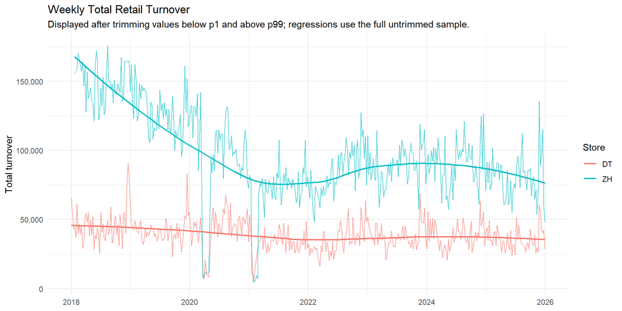

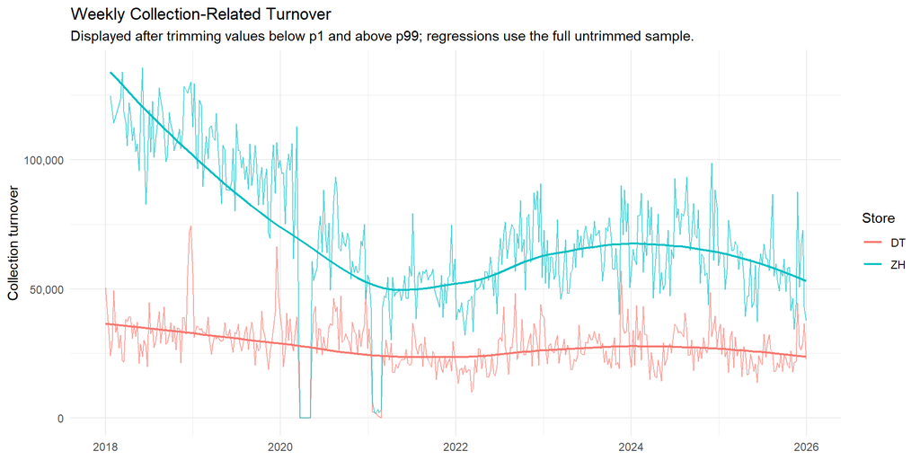

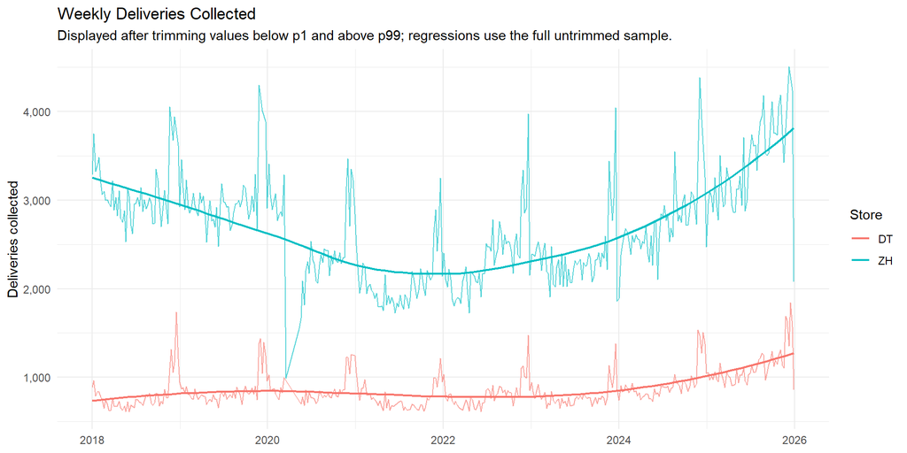

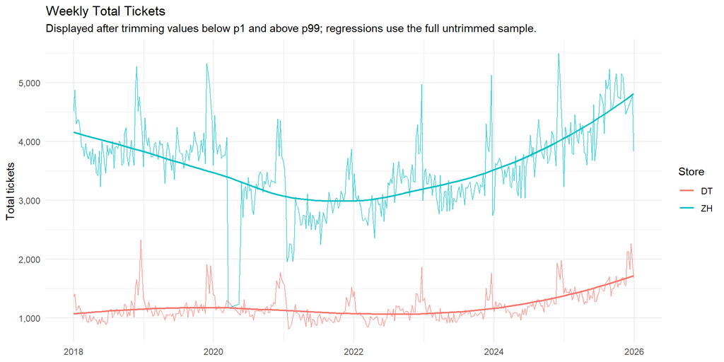

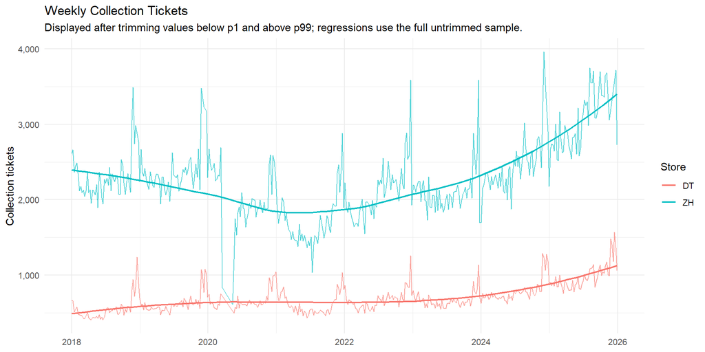

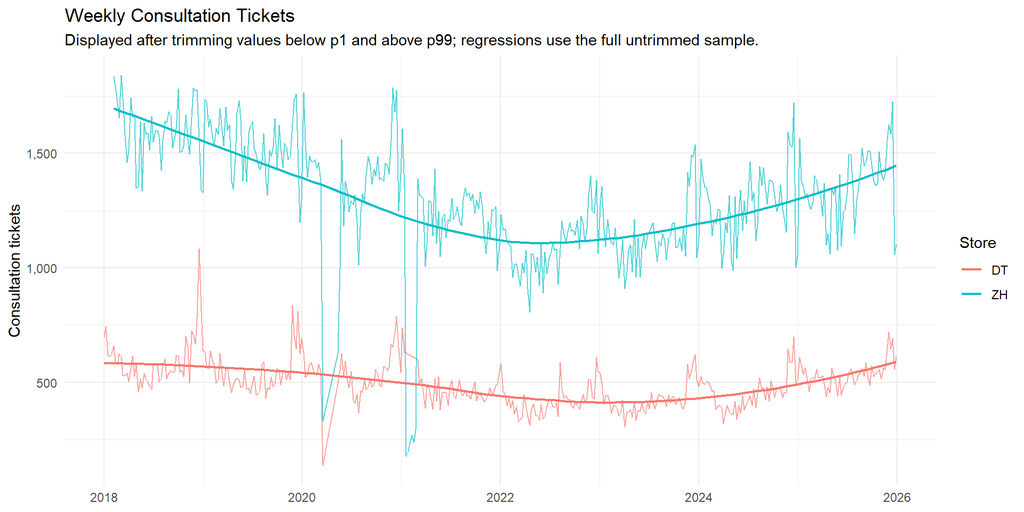

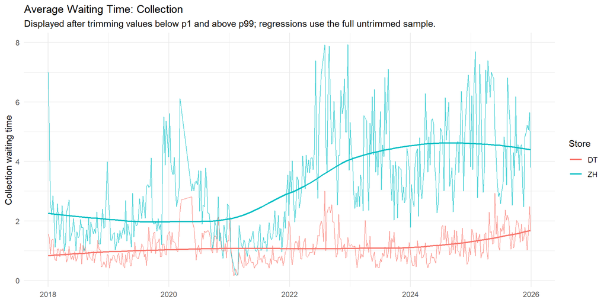

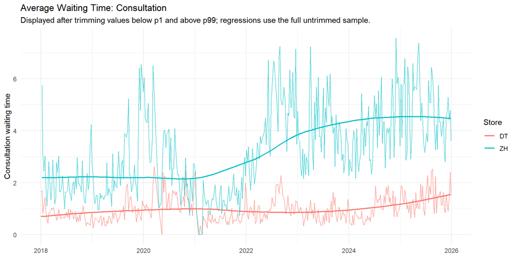

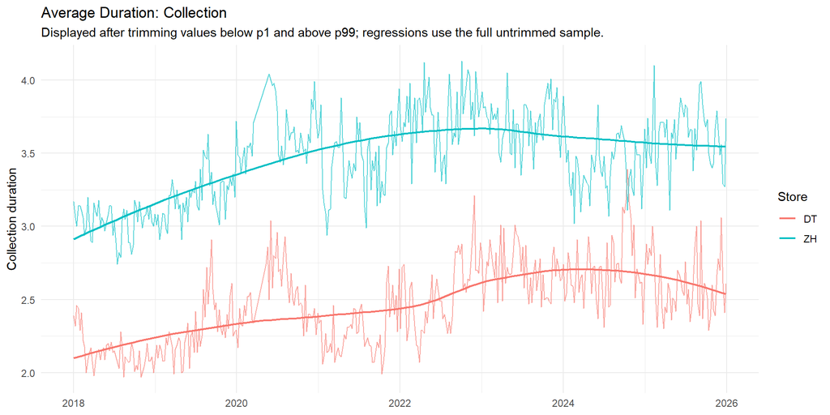

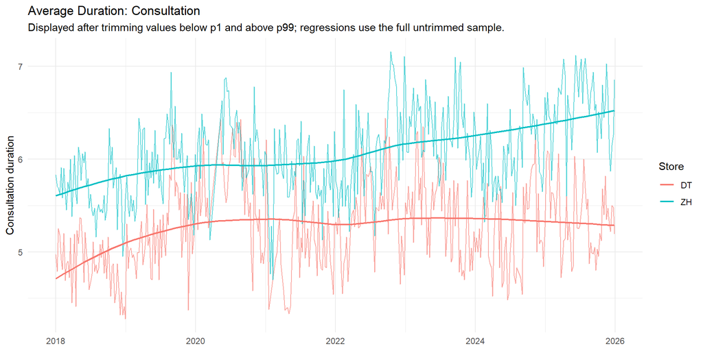

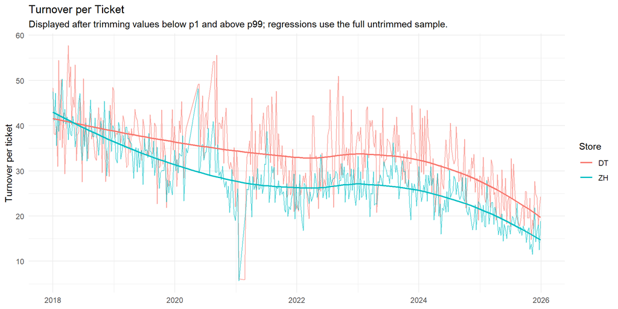

```r
figure_vars <- c(
  total_turnover = "Weekly Total Retail Turnover",
  collection_turnover = "Weekly Collection-Related Turnover",
  deliveries_collected = "Weekly Deliveries Collected",
  total_tickets = "Weekly Total Tickets",
  tickets_abholung = "Weekly Collection Tickets",
  tickets_beratung = "Weekly Consultation Tickets",
  avg_waiting_time_abholung = "Average Waiting Time: Collection",
  avg_waiting_time_beratung = "Average Waiting Time: Consultation",
  avg_duration_abholung = "Average Duration: Collection",
  avg_duration_beratung = "Average Duration: Consultation",
  throughput_proxy = "Turnover per Ticket"
)

for (v in names(figure_vars)) {
  y_label <- if (v %in% names(model_label_map)) {
    unname(model_label_map[v])
  } else {
    v
  }

  p <- plot_weekly_series(weekly_panel, v, figure_vars[[v]], y_label = y_label)
  if (!is.null(p)) {
    print(p)
    ggsave(
      filename = file.path(output_dir, "figures", paste0("weekly_", v, ".png")),
      plot = p,
      width = 10,
      height = 5,
      bg = "white"
    )
    save_plot_png(p, paste0("fig_weekly_", v, ".png"), width = 10, height = 5)
  }
}
```

# 4 Baseline Fixed-Effects Models: Period Comparison

The following tables are formatted for empirical review. The full table files are also exported separately in the output folder and can be copied into the thesis appendix if needed.

The period models compare COVID, Post-COVID and New Normal with Pre-COVID as the omitted baseline. In this two-store setting, full calendar-week fixed effects would absorb the period variables. The baseline therefore uses store fixed effects and week-of-year fixed effects. A linear time trend is included in selected robustness specifications.

## 4.1 Commercial Outcomes

```r
commercial_outcomes <- c(
  "total_turnover",
  "direct_turnover",
  "direct_turnover_all",
  "direct_turnover_relevant",
  "turnover_ordered_collection",
  "turnover_added_collection",
  "collection_turnover",
  "turnover_collected",
  "deliveries_collected",
  "turnover_per_ticket",
  "throughput_proxy"
)

commercial_outcomes <- available_vars(commercial_outcomes, weekly_panel)

models_period_commercial_log <- map(
  commercial_outcomes,
  ~ run_fe_model(
    data = weekly_panel,
    outcome = .x,
    rhs = "covid + postcovid + newnormal",
    model_group = "Period commercial",
    transform = "log",
    fixed_effects = "store + week_of_year_fe"
  )
)
names(models_period_commercial_log) <- commercial_outcomes
models_period_commercial_log <- compact(models_period_commercial_log)

period_commercial_core_models <- select_model_subset(models_period_commercial_log, c("total_turnover", "collection_turnover", "deliveries_collected", "throughput_proxy"))
display_model_table(
  period_commercial_core_models,
  "Period comparison for core commercial outcomes"
)
```

Period comparison for core commercial outcomes

|  | Total turnover | Collection turnover | Deliveries collected | Turnover per ticket |
| --- | --- | --- | --- | --- |
| COVID (2020--2021) | -0.564*** | -0.601*** | -0.301*** | -0.230*** |
|  | (0.058) | (0.061) | (0.064) | (0.048) |
| Post-COVID (2022--2023) | -0.346*** | -0.423*** | -0.154*** | -0.219*** |
|  | (0.025) | (0.026) | (0.017) | (0.019) |
| New Normal (2024--2025) | -0.347*** | -0.406*** | 0.108*** | -0.454*** |
|  | (0.025) | (0.027) | (0.018) | (0.023) |
| Observations | 836 | 822 | 825 | 825 |
| R2 | 0.607 | 0.604 | 0.685 | 0.271 |
| Within R2 | 0.182 | 0.199 | 0.119 | 0.173 |

Heteroskedasticity-robust standard errors in parentheses.  
Weekly models include store and week-of-year fixed effects unless stated otherwise.  
Dependent variables are log-transformed unless the table states otherwise.  
Significance levels: *** p < 0.001, ** p < 0.01, * p < 0.05.

```r
save_model_table(period_commercial_core_models, "tab_period_commercial_core.png", "Period comparison for core commercial outcomes")
save_model_table(models_period_commercial_log, "period_models_commercial_log.html", "Period Models: Commercial Outcomes")
```

```r
level_table_notes <- c(
  "Heteroskedasticity-robust standard errors in parentheses.",
  "Weekly models include store and week-of-year fixed effects unless stated otherwise.",
  "Dependent variables are estimated in levels.",
  significance_note
)

models_period_commercial_level <- map(
  commercial_outcomes,
  ~ run_fe_model(
    data = weekly_panel,
    outcome = .x,
    rhs = "covid + postcovid + newnormal",
    model_group = "Period commercial levels",
    transform = "level",
    fixed_effects = "store + week_of_year_fe"
  )
)
names(models_period_commercial_level) <- commercial_outcomes
models_period_commercial_level <- compact(models_period_commercial_level)

period_commercial_core_models_level <- select_model_subset(
  models_period_commercial_level,
  c("total_turnover", "collection_turnover", "deliveries_collected", "throughput_proxy")
)

display_model_table(
  period_commercial_core_models_level,
  "Period comparison for core commercial outcomes in levels",
  notes = level_table_notes
)
```

Period comparison for core commercial outcomes in levels

|  | Total turnover | Collection turnover | Deliveries collected | Turnover per ticket |
| --- | --- | --- | --- | --- |
| COVID (2020--2021) | -34919.271*** | -32535.876*** | -490.495*** | -0.725 |
|  | (2594.160) | (2081.926) | (39.936) | (3.036) |
| Post-COVID (2022--2023) | -31469.998*** | -27771.807*** | -401.220*** | -7.187*** |
|  | (2044.796) | (1711.949) | (31.145) | (0.823) |
| New Normal (2024--2025) | -32019.444*** | -26992.018*** | 114.748** | -13.158*** |
|  | (2055.414) | (1697.456) | (38.142) | (0.820) |
| Observations | 836 | 836 | 825 | 825 |
| R2 | 0.743 | 0.722 | 0.886 | 0.144 |
| Within R2 | 0.335 | 0.380 | 0.335 | 0.065 |

Heteroskedasticity-robust standard errors in parentheses.  
Weekly models include store and week-of-year fixed effects unless stated otherwise.  
Dependent variables are estimated in levels.  
Significance levels: *** p < 0.001, ** p < 0.01, * p < 0.05.

```r
save_model_table(
  period_commercial_core_models_level,
  "tab_period_commercial_core_levels.png",
  "Period comparison for core commercial outcomes in levels",
  notes = level_table_notes
)

save_model_table(
  models_period_commercial_level,
  "period_models_commercial_levels.html",
  "Period Models: Commercial Outcomes in Levels",
  notes = level_table_notes
)
```

## 4.2 Operational Outcomes

```r
operational_outcomes <- c(
  "total_tickets",
  "tickets_abholung",
  "tickets_beratung",
  "avg_waiting_time_abholung",
  "avg_waiting_time_beratung",
  "median_waiting_time_abholung",
  "median_waiting_time_beratung",
  "avg_duration_abholung",
  "avg_duration_beratung",
  "median_duration_abholung",
  "median_duration_beratung",
  "consultation_ratio",
  "collection_workload",
  "consultation_workload",
  "workload_proxy",
  "throughput_proxy",
  "productivity"
)

operational_outcomes <- available_vars(operational_outcomes, weekly_panel)

models_period_operational_log <- map(
  operational_outcomes,
  ~ run_fe_model(
    data = weekly_panel,
    outcome = .x,
    rhs = "covid + postcovid + newnormal",
    model_group = "Period operational",
    transform = "log",
    fixed_effects = "store + week_of_year_fe"
  )
)
names(models_period_operational_log) <- operational_outcomes
models_period_operational_log <- compact(models_period_operational_log)

# Consultation share is estimated in levels.
model_period_consultation_share <- run_fe_model(
  data = weekly_panel,
  outcome = "consultation_share",
  rhs = "covid + postcovid + newnormal",
  model_group = "Period operational",
  transform = "level",
  fixed_effects = "store + week_of_year_fe"
)

period_ticket_models <- select_model_subset(c(models_period_operational_log, list(consultation_share = model_period_consultation_share)),
                      c("total_tickets", "tickets_abholung", "tickets_beratung", "consultation_share"))
period_waiting_duration_models <- select_model_subset(models_period_operational_log,
                      c("avg_waiting_time_abholung", "avg_waiting_time_beratung", "avg_duration_abholung", "avg_duration_beratung"))

display_model_table(
  period_ticket_models,
  "Period comparison for ticket volume and service composition"
)
```

Period comparison for ticket volume and service composition

|  | Total tickets | Collection tickets | Consultation tickets | Consultation share |
| --- | --- | --- | --- | --- |
| COVID (2020--2021) | -0.281*** | -0.117*** | -0.413*** | -0.027** |
|  | (0.060) | (0.018) | (0.065) | (0.009) |
| Post-COVID (2022--2023) | -0.133*** | 0.012 | -0.330*** | -0.083*** |
|  | (0.017) | (0.013) | (0.017) | (0.004) |
| New Normal (2024--2025) | 0.104*** | 0.289*** | -0.169*** | -0.109*** |
|  | (0.017) | (0.015) | (0.018) | (0.004) |
| Observations | 825 | 822 | 825 | 825 |
| R2 | 0.684 | 0.948 | 0.604 | 0.431 |
| Within R2 | 0.110 | 0.498 | 0.112 | 0.323 |

Heteroskedasticity-robust standard errors in parentheses.  
Weekly models include store and week-of-year fixed effects unless stated otherwise.  
Dependent variables are log-transformed unless the table states otherwise.  
Significance levels: *** p < 0.001, ** p < 0.01, * p < 0.05.

```r
save_model_table(period_ticket_models, "tab_period_ticket_volume_service_composition.png", "Period comparison for ticket volume and service composition")

display_model_table(
  period_waiting_duration_models,
  "Period comparison for waiting time and duration"
)
```

Period comparison for waiting time and duration

|  | Collection waiting time | Consultation waiting time | Collection duration | Consultation duration |
| --- | --- | --- | --- | --- |
| COVID (2020--2021) | -0.107 | -0.096 | 0.103*** | 0.019 |
|  | (0.060) | (0.080) | (0.008) | (0.021) |
| Post-COVID (2022--2023) | 0.468*** | 0.412*** | 0.176*** | 0.070*** |
|  | (0.038) | (0.039) | (0.007) | (0.008) |
| New Normal (2024--2025) | 0.548*** | 0.530*** | 0.153*** | 0.071*** |
|  | (0.038) | (0.039) | (0.007) | (0.008) |
| Observations | 820 | 818 | 822 | 825 |
| R2 | 0.617 | 0.579 | 0.862 | 0.228 |
| Within R2 | 0.256 | 0.170 | 0.453 | 0.040 |

Heteroskedasticity-robust standard errors in parentheses.  
Weekly models include store and week-of-year fixed effects unless stated otherwise.  
Dependent variables are log-transformed unless the table states otherwise.  
Significance levels: *** p < 0.001, ** p < 0.01, * p < 0.05.

```r
save_model_table(period_waiting_duration_models, "tab_period_waiting_time_duration.png", "Period comparison for waiting time and duration")

save_model_table(c(models_period_operational_log, list(consultation_share = model_period_consultation_share)),
                 "period_models_operational.html",
                 "Period Models: Operational Outcomes")
```

```r
models_period_operational_level <- map(
  operational_outcomes,
  ~ run_fe_model(
    data = weekly_panel,
    outcome = .x,
    rhs = "covid + postcovid + newnormal",
    model_group = "Period operational levels",
    transform = "level",
    fixed_effects = "store + week_of_year_fe"
  )
)
names(models_period_operational_level) <- operational_outcomes
models_period_operational_level <- compact(models_period_operational_level)

# Consultation share is already a level outcome and is kept in the level-output table.
model_period_consultation_share_level <- run_fe_model(
  data = weekly_panel,
  outcome = "consultation_share",
  rhs = "covid + postcovid + newnormal",
  model_group = "Period operational levels",
  transform = "level",
  fixed_effects = "store + week_of_year_fe"
)

period_ticket_models_level <- select_model_subset(
  c(models_period_operational_level, list(consultation_share = model_period_consultation_share_level)),
  c("total_tickets", "tickets_abholung", "tickets_beratung", "consultation_share")
)

period_waiting_duration_models_level <- select_model_subset(
  models_period_operational_level,
  c("avg_waiting_time_abholung", "avg_waiting_time_beratung", "avg_duration_abholung", "avg_duration_beratung")
)

display_model_table(
  period_ticket_models_level,
  "Period comparison for ticket volume and service composition in levels",
  notes = level_table_notes
)
```

Period comparison for ticket volume and service composition in levels

|  | Total tickets | Collection tickets | Consultation tickets | Consultation share |
| --- | --- | --- | --- | --- |
| COVID (2020--2021) | -546.312*** | -294.371*** | -251.865*** | -0.027** |
|  | (45.876) | (31.567) | (22.375) | (0.009) |
| Post-COVID (2022--2023) | -415.353*** | -99.571*** | -315.938*** | -0.083*** |
|  | (30.426) | (21.838) | (13.320) | (0.004) |
| New Normal (2024--2025) | 188.933*** | 369.505*** | -180.795*** | -0.109*** |
|  | (39.076) | (32.165) | (13.084) | (0.004) |
| Observations | 825 | 825 | 825 | 825 |
| R2 | 0.912 | 0.891 | 0.876 | 0.431 |
| Within R2 | 0.356 | 0.386 | 0.342 | 0.323 |

Heteroskedasticity-robust standard errors in parentheses.  
Weekly models include store and week-of-year fixed effects unless stated otherwise.  
Dependent variables are estimated in levels.  
Significance levels: *** p < 0.001, ** p < 0.01, * p < 0.05.

```r
save_model_table(
  period_ticket_models_level,
  "tab_period_ticket_volume_service_composition_levels.png",
  "Period comparison for ticket volume and service composition in levels",
  notes = level_table_notes
)

display_model_table(
  period_waiting_duration_models_level,
  "Period comparison for waiting time and duration in levels",
  notes = level_table_notes
)
```

Period comparison for waiting time and duration in levels

|  | Collection waiting time | Consultation waiting time | Collection duration | Consultation duration |
| --- | --- | --- | --- | --- |
| COVID (2020--2021) | 0.008 | 0.229 | 0.309*** | 0.229* |
|  | (0.135) | (0.313) | (0.025) | (0.093) |
| Post-COVID (2022--2023) | 1.221*** | 1.017*** | 0.518*** | 0.397*** |
|  | (0.111) | (0.119) | (0.020) | (0.040) |
| New Normal (2024--2025) | 1.403*** | 1.193*** | 0.426*** | 0.415*** |
|  | (0.114) | (0.114) | (0.020) | (0.044) |
| Observations | 822 | 825 | 822 | 825 |
| R2 | 0.531 | 0.261 | 0.854 | 0.305 |
| Within R2 | 0.212 | 0.048 | 0.430 | 0.055 |

Heteroskedasticity-robust standard errors in parentheses.  
Weekly models include store and week-of-year fixed effects unless stated otherwise.  
Dependent variables are estimated in levels.  
Significance levels: *** p < 0.001, ** p < 0.01, * p < 0.05.

```r
save_model_table(
  period_waiting_duration_models_level,
  "tab_period_waiting_time_duration_levels.png",
  "Period comparison for waiting time and duration in levels",
  notes = level_table_notes
)

save_model_table(
  c(models_period_operational_level, list(consultation_share = model_period_consultation_share_level)),
  "period_models_operational_levels.html",
  "Period Models: Operational Outcomes in Levels",
  notes = level_table_notes
)
```

# 5 Event-Based Fixed-Effects Models

Event models are estimated only if the corresponding event date is filled in and the event dummy has variation. Models that cannot be estimated are automatically logged in `model_log`.

```r
event_date_audit <- tibble(
  event = c("CHF 4.90 small-order fee", "STEG exit", "melectronics exit", "Same-day delivery cancellation"),
  exact_event_date = c(fee_date, steg_date, melectronics_date, same_day_end_date),
  weekly_event_start = event_week_start(exact_event_date),
  status = if_else(is.na(exact_event_date), "Missing: model skipped", "Available")
)

knitr::kable(
  event_date_audit,
  caption = "Event dates used in event-based specifications"
)
```

Event dates used in event-based specifications

| event | exact_event_date | weekly_event_start | status |
| --- | --- | --- | --- |
| CHF 4.90 small-order fee | 2024-10-01 | 2024-09-30 | Available |
| STEG exit | 2023-09-08 | 2023-09-04 | Available |
| melectronics exit | 2024-11-30 | 2024-11-25 | Available |
| Same-day delivery cancellation | 2025-09-29 | 2025-09-29 | Available |

```r
save_df_table_png(
  event_date_audit,
  "tab_event_dates.png",
  title = "Event dates used in event-based specifications",
  note = "Weekly event start is the Monday of the week containing the event date.",
  digits = 0
)
```

The fee and competitor models require confirmed event dates. If the event date is still missing, the corresponding model is not estimated, because an event dummy without variation would produce invalid or misleading results.

## 5.1 CHF 4.90 Small-Order Fee

```r
fee_outcomes <- c(
  "turnover_ordered_collection",
  "turnover_added_collection",
  "collection_turnover",
  "turnover_collected",
  "deliveries_collected",
  "tickets_abholung",
  "total_tickets",
  "avg_waiting_time_abholung",
  "throughput_proxy",
  "productivity"
)
fee_outcomes <- available_vars(fee_outcomes, weekly_panel)

models_fee <- map(
  fee_outcomes,
  ~ run_fe_model(
    data = weekly_panel,
    outcome = .x,
    rhs = "fee_post",
    model_group = "Fee event",
    transform = "log",
    fixed_effects = "store + week_of_year_fe"
  )
)
names(models_fee) <- fee_outcomes
models_fee <- compact(models_fee)

fee_commercial_models <- select_model_subset(models_fee, c("collection_turnover", "turnover_ordered_collection", "turnover_added_collection", "deliveries_collected"))
fee_operational_models <- select_model_subset(models_fee, c("tickets_abholung", "total_tickets", "avg_waiting_time_abholung", "throughput_proxy"))

display_model_table(
  fee_commercial_models,
  "CHF 4.90 fee and collection-related commercial outcomes"
)
```

CHF 4.90 fee and collection-related commercial outcomes

|  | Collection turnover | Ordered for collection | Added for collection | Deliveries collected |
| --- | --- | --- | --- | --- |
| After CHF 4.90 fee | -0.133*** | -0.115*** | -0.420*** | 0.309*** |
|  | (0.029) | (0.030) | (0.067) | (0.021) |
| Observations | 822 | 822 | 822 | 825 |
| R2 | 0.510 | 0.481 | 0.520 | 0.665 |
| Within R2 | 0.010 | 0.007 | 0.046 | 0.064 |

Heteroskedasticity-robust standard errors in parentheses.  
Weekly models include store and week-of-year fixed effects unless stated otherwise.  
Dependent variables are log-transformed unless the table states otherwise.  
Significance levels: *** p < 0.001, ** p < 0.01, * p < 0.05.

```r
save_model_table(fee_commercial_models, "tab_fee_commercial_outcomes.png", "CHF 4.90 fee and collection-related commercial outcomes")

display_model_table(
  fee_operational_models,
  "CHF 4.90 fee and operational pressure"
)
```

CHF 4.90 fee and operational pressure

|  | Collection tickets | Total tickets | Collection waiting time | Turnover per ticket |
| --- | --- | --- | --- | --- |
| After CHF 4.90 fee | 0.380*** | 0.283*** | 0.500*** | -0.389*** |
|  | (0.012) | (0.021) | (0.039) | (0.024) |
| Observations | 822 | 825 | 820 | 825 |
| R2 | 0.941 | 0.665 | 0.540 | 0.235 |
| Within R2 | 0.430 | 0.057 | 0.106 | 0.131 |

Heteroskedasticity-robust standard errors in parentheses.  
Weekly models include store and week-of-year fixed effects unless stated otherwise.  
Dependent variables are log-transformed unless the table states otherwise.  
Significance levels: *** p < 0.001, ** p < 0.01, * p < 0.05.

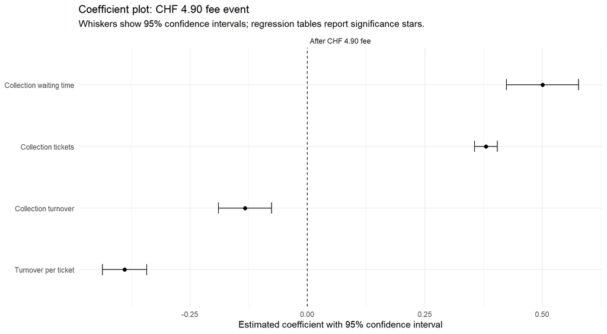

```r
save_model_table(fee_operational_models, "tab_fee_operational_pressure.png", "CHF 4.90 fee and operational pressure")

plot_event_coefficients(
  select_model_subset(models_fee, c("collection_turnover", "tickets_abholung", "avg_waiting_time_abholung", "throughput_proxy")),
  "Coefficient plot: CHF 4.90 fee event",
  "coefplot_fee_event.png"
)
```

```r
save_model_table(models_fee, "fee_event_models.html", "Fee Event Models")
```

```r
models_fee_level <- map(
  fee_outcomes,
  ~ run_fe_model(
    data = weekly_panel,
    outcome = .x,
    rhs = "fee_post",
    model_group = "Fee event levels",
    transform = "level",
    fixed_effects = "store + week_of_year_fe"
  )
)
names(models_fee_level) <- fee_outcomes
models_fee_level <- compact(models_fee_level)

fee_commercial_models_level <- select_model_subset(
  models_fee_level,
  c("collection_turnover", "turnover_ordered_collection", "turnover_added_collection", "deliveries_collected")
)

fee_operational_models_level <- select_model_subset(
  models_fee_level,
  c("tickets_abholung", "total_tickets", "avg_waiting_time_abholung", "throughput_proxy")
)

display_model_table(
  fee_commercial_models_level,
  "CHF 4.90 fee and collection-related commercial outcomes in levels",
  notes = level_table_notes
)
```

CHF 4.90 fee and collection-related commercial outcomes in levels

|  | Collection turnover | Ordered for collection | Added for collection | Deliveries collected |
| --- | --- | --- | --- | --- |
| After CHF 4.90 fee | -9453.563*** | -8716.393*** | -1522.815*** | 548.362*** |
|  | (1279.152) | (1164.940) | (185.602) | (41.337) |
| Observations | 836 | 822 | 822 | 825 |
| R2 | 0.563 | 0.586 | 0.470 | 0.864 |
| Within R2 | 0.027 | 0.030 | 0.055 | 0.203 |

Heteroskedasticity-robust standard errors in parentheses.  
Weekly models include store and week-of-year fixed effects unless stated otherwise.  
Dependent variables are estimated in levels.  
Significance levels: *** p < 0.001, ** p < 0.01, * p < 0.05.

```r
save_model_table(
  fee_commercial_models_level,
  "tab_fee_commercial_outcomes_levels.png",
  "CHF 4.90 fee and collection-related commercial outcomes in levels",
  notes = level_table_notes
)

display_model_table(
  fee_operational_models_level,
  "CHF 4.90 fee and operational pressure in levels",
  notes = level_table_notes
)
```

CHF 4.90 fee and operational pressure in levels

|  | Collection tickets | Total tickets | Collection waiting time | Turnover per ticket |
| --- | --- | --- | --- | --- |
| After CHF 4.90 fee | 623.171*** | 654.430*** | 1.190*** | -11.754*** |
|  | (38.017) | (43.573) | (0.135) | (0.989) |
| Observations | 825 | 825 | 822 | 825 |
| R2 | 0.884 | 0.894 | 0.460 | 0.122 |
| Within R2 | 0.342 | 0.227 | 0.092 | 0.041 |

Heteroskedasticity-robust standard errors in parentheses.  
Weekly models include store and week-of-year fixed effects unless stated otherwise.  
Dependent variables are estimated in levels.  
Significance levels: *** p < 0.001, ** p < 0.01, * p < 0.05.

```r
save_model_table(
  fee_operational_models_level,
  "tab_fee_operational_pressure_levels.png",
  "CHF 4.90 fee and operational pressure in levels",
  notes = level_table_notes
)

save_model_table(
  models_fee_level,
  "fee_event_models_levels.html",
  "Fee Event Models in Levels",
  notes = level_table_notes
)
```

## 5.2 Competitor Exits

```r
competitor_outcomes <- c(
  "tickets_beratung",
  "consultation_ratio",
  "consultation_share",
  "avg_waiting_time_beratung",
  "median_waiting_time_beratung",
  "avg_duration_beratung",
  "median_duration_beratung",
  "consultation_workload",
  "workload_proxy",
  "throughput_proxy",
  "productivity"
)
competitor_outcomes <- available_vars(competitor_outcomes, weekly_panel)

competitor_rhs <- "steg_post + melectronics_post"

models_competitor_log <- map(
  setdiff(competitor_outcomes, "consultation_share"),
  ~ run_fe_model(
    data = weekly_panel,
    outcome = .x,
    rhs = competitor_rhs,
    model_group = "Competitor events",
    transform = "log",
    fixed_effects = "store + week_of_year_fe"
  )
)
names(models_competitor_log) <- setdiff(competitor_outcomes, "consultation_share")
models_competitor_log <- compact(models_competitor_log)

model_competitor_share <- run_fe_model(
  data = weekly_panel,
  outcome = "consultation_share",
  rhs = competitor_rhs,
  model_group = "Competitor events",
  transform = "level",
  fixed_effects = "store + week_of_year_fe"
)

competitor_service_models <- select_model_subset(c(models_competitor_log, list(consultation_share = model_competitor_share)),
                      c("tickets_beratung", "consultation_share", "consultation_ratio", "avg_duration_beratung"))
competitor_pressure_models <- select_model_subset(models_competitor_log,
                      c("avg_waiting_time_beratung", "workload_proxy", "consultation_workload", "throughput_proxy"))

display_model_table(
  competitor_service_models,
  "Competitor exits and service composition"
)
```

Competitor exits and service composition

|  | Consultation tickets | Consultation share | Consultation ratio | Consultation duration |
| --- | --- | --- | --- | --- |
| After STEG exit | -0.023 | -0.053*** | -0.194*** | 0.011 |
|  | (0.025) | (0.005) | (0.021) | (0.010) |
| After melectronics exit | 0.136*** | -0.033*** | -0.147*** | 0.061*** |
|  | (0.022) | (0.004) | (0.020) | (0.010) |
| Observations | 825 | 825 | 822 | 825 |
| R2 | 0.558 | 0.311 | 0.240 | 0.215 |
| Within R2 | 0.008 | 0.179 | 0.122 | 0.024 |

Heteroskedasticity-robust standard errors in parentheses.  
Weekly models include store and week-of-year fixed effects unless stated otherwise.  
Dependent variables are log-transformed unless the table states otherwise.  
Significance levels: *** p < 0.001, ** p < 0.01, * p < 0.05.

```r
save_model_table(competitor_service_models, "tab_competitor_service_composition.png", "Competitor exits and service composition")

display_model_table(
  competitor_pressure_models,
  "Competitor exits and operational pressure"
)
```

Competitor exits and operational pressure

|  | Consultation waiting time | Workload proxy | Consultation workload | Turnover per ticket |
| --- | --- | --- | --- | --- |
| After STEG exit | 0.230*** | 0.053*** | -0.013 | -0.127*** |
|  | (0.044) | (0.012) | (0.029) | (0.024) |
| After melectronics exit | 0.333*** | 0.239*** | 0.197*** | -0.306*** |
|  | (0.047) | (0.014) | (0.026) | (0.028) |
| Observations | 818 | 822 | 825 | 825 |
| R2 | 0.541 | 0.950 | 0.545 | 0.247 |
| Within R2 | 0.097 | 0.290 | 0.014 | 0.146 |

Heteroskedasticity-robust standard errors in parentheses.  
Weekly models include store and week-of-year fixed effects unless stated otherwise.  
Dependent variables are log-transformed unless the table states otherwise.  
Significance levels: *** p < 0.001, ** p < 0.01, * p < 0.05.

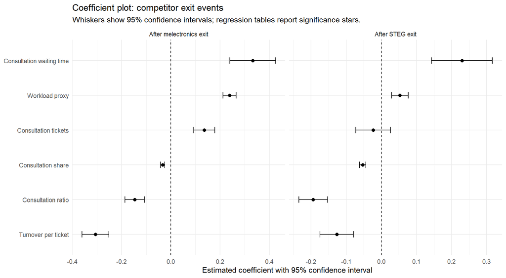

```r
save_model_table(competitor_pressure_models, "tab_competitor_operational_pressure.png", "Competitor exits and operational pressure")

plot_event_coefficients(
  select_model_subset(c(models_competitor_log, list(consultation_share = model_competitor_share)),
                      c("tickets_beratung", "consultation_share", "consultation_ratio", "avg_waiting_time_beratung", "workload_proxy", "throughput_proxy")),
  "Coefficient plot: competitor exit events",
  "coefplot_competitor_events.png"
)
```

```r
save_model_table(c(models_competitor_log, list(consultation_share = model_competitor_share)),
                 "competitor_event_models.html",
                 "Competitor Event Models")
```

```r
models_competitor_level <- map(
  setdiff(competitor_outcomes, "consultation_share"),
  ~ run_fe_model(
    data = weekly_panel,
    outcome = .x,
    rhs = competitor_rhs,
    model_group = "Competitor events levels",
    transform = "level",
    fixed_effects = "store + week_of_year_fe"
  )
)
names(models_competitor_level) <- setdiff(competitor_outcomes, "consultation_share")
models_competitor_level <- compact(models_competitor_level)

model_competitor_share_level <- run_fe_model(
  data = weekly_panel,
  outcome = "consultation_share",
  rhs = competitor_rhs,
  model_group = "Competitor events levels",
  transform = "level",
  fixed_effects = "store + week_of_year_fe"
)

competitor_service_models_level <- select_model_subset(
  c(models_competitor_level, list(consultation_share = model_competitor_share_level)),
  c("tickets_beratung", "consultation_share", "consultation_ratio", "avg_duration_beratung")
)

competitor_pressure_models_level <- select_model_subset(
  models_competitor_level,
  c("avg_waiting_time_beratung", "workload_proxy", "consultation_workload", "throughput_proxy")
)

display_model_table(
  competitor_service_models_level,
  "Competitor exits and service composition in levels",
  notes = level_table_notes
)
```

Competitor exits and service composition in levels

|  | Consultation tickets | Consultation share | Consultation ratio | Consultation duration |
| --- | --- | --- | --- | --- |
| After STEG exit | -64.778*** | -0.053*** | -0.157*** | 0.033 |
|  | (12.506) | (0.005) | (0.011) | (0.049) |
| After melectronics exit | 96.240*** | -0.033*** | -0.074*** | 0.362*** |
|  | (12.368) | (0.004) | (0.010) | (0.060) |
| Observations | 825 | 825 | 822 | 825 |
| R2 | 0.815 | 0.311 | 0.368 | 0.290 |
| Within R2 | 0.018 | 0.179 | 0.221 | 0.035 |

Heteroskedasticity-robust standard errors in parentheses.  
Weekly models include store and week-of-year fixed effects unless stated otherwise.  
Dependent variables are estimated in levels.  
Significance levels: *** p < 0.001, ** p < 0.01, * p < 0.05.

```r
save_model_table(
  competitor_service_models_level,
  "tab_competitor_service_composition_levels.png",
  "Competitor exits and service composition in levels",
  notes = level_table_notes
)

display_model_table(
  competitor_pressure_models_level,
  "Competitor exits and operational pressure in levels",
  notes = level_table_notes
)
```

Competitor exits and operational pressure in levels

|  | Consultation waiting time | Workload proxy | Consultation workload | Turnover per ticket |
| --- | --- | --- | --- | --- |
| After STEG exit | 0.375** | 400.886** | -270.590*** | -5.927*** |
|  | (0.127) | (126.576) | (76.399) | (1.154) |
| After melectronics exit | 0.731*** | 2778.529*** | 939.859*** | -7.514*** |
|  | (0.142) | (237.897) | (93.528) | (0.984) |
| Observations | 825 | 822 | 825 | 825 |
| R2 | 0.245 | 0.925 | 0.850 | 0.131 |
| Within R2 | 0.027 | 0.282 | 0.050 | 0.052 |

Heteroskedasticity-robust standard errors in parentheses.  
Weekly models include store and week-of-year fixed effects unless stated otherwise.  
Dependent variables are estimated in levels.  
Significance levels: *** p < 0.001, ** p < 0.01, * p < 0.05.

```r
save_model_table(
  competitor_pressure_models_level,
  "tab_competitor_operational_pressure_levels.png",
  "Competitor exits and operational pressure in levels",
  notes = level_table_notes
)

save_model_table(
  c(models_competitor_level, list(consultation_share = model_competitor_share_level)),
  "competitor_event_models_levels.html",
  "Competitor Event Models in Levels",
  notes = level_table_notes
)
```

## 5.3 Same-Day Delivery Cancellation

```r
same_day_outcomes <- c(
  "turnover_ordered_collection",
  "turnover_added_collection",
  "collection_turnover",
  "turnover_ordered_shipment",
  "turnover_added_shipment",
  "shipment_turnover",
  "turnover_collected",
  "deliveries_collected",
  "total_tickets",
  "tickets_abholung",
  "avg_waiting_time_abholung",
  "throughput_proxy",
  "productivity"
)
same_day_outcomes <- available_vars(same_day_outcomes, weekly_panel)

models_same_day <- map(
  same_day_outcomes,
  ~ run_fe_model(
    data = weekly_panel,
    outcome = .x,
    rhs = "same_day_end_post",
    model_group = "Same-day cancellation",
    transform = "log",
    fixed_effects = "store + week_of_year_fe"
  )
)
names(models_same_day) <- same_day_outcomes
models_same_day <- compact(models_same_day)

same_day_commercial_models <- select_model_subset(models_same_day, c("collection_turnover", "deliveries_collected", "shipment_turnover", "turnover_collected"))
same_day_operational_models <- select_model_subset(models_same_day, c("total_tickets", "tickets_abholung", "avg_waiting_time_abholung", "throughput_proxy"))

display_model_table(
  same_day_commercial_models,
  "Same-day delivery cancellation and commercial outcomes"
)
```

Same-day delivery cancellation and commercial outcomes

|  | Collection turnover | Deliveries collected | Shipment turnover | Turnover collected |
| --- | --- | --- | --- | --- |
| After same-day delivery cancellation | -0.262*** | 0.324*** | -0.066 | -0.055 |
|  | (0.048) | (0.031) | (0.075) | (0.038) |
| Observations | 822 | 825 | 836 | 823 |
| R2 | 0.509 | 0.648 | 0.555 | 0.806 |
| Within R2 | 0.008 | 0.016 | 0.001 | 0.001 |

Heteroskedasticity-robust standard errors in parentheses.  
Weekly models include store and week-of-year fixed effects unless stated otherwise.  
Dependent variables are log-transformed unless the table states otherwise.  
Significance levels: *** p < 0.001, ** p < 0.01, * p < 0.05.

```r
save_model_table(same_day_commercial_models, "tab_same_day_commercial_outcomes.png", "Same-day delivery cancellation and commercial outcomes")

display_model_table(
  same_day_operational_models,
  "Same-day delivery cancellation and operational pressure"
)
```

Same-day delivery cancellation and operational pressure

|  | Total tickets | Collection tickets | Collection waiting time | Turnover per ticket |
| --- | --- | --- | --- | --- |
| After same-day delivery cancellation | 0.296*** | 0.427*** | 0.469*** | -0.478*** |
|  | (0.019) | (0.023) | (0.051) | (0.037) |
| Observations | 825 | 822 | 820 | 825 |
| R2 | 0.650 | 0.909 | 0.497 | 0.158 |
| Within R2 | 0.014 | 0.123 | 0.021 | 0.045 |

Heteroskedasticity-robust standard errors in parentheses.  
Weekly models include store and week-of-year fixed effects unless stated otherwise.  
Dependent variables are log-transformed unless the table states otherwise.  
Significance levels: *** p < 0.001, ** p < 0.01, * p < 0.05.

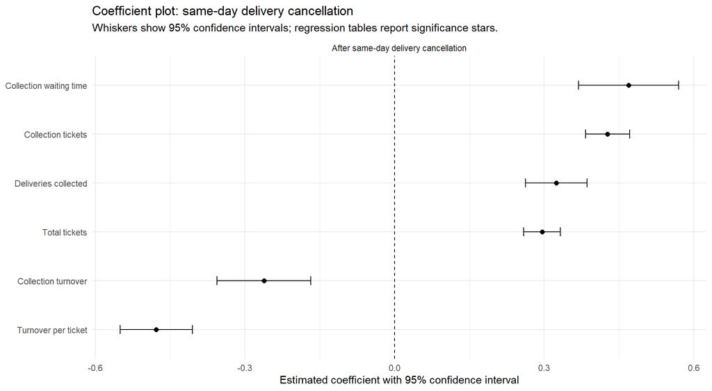

```r
save_model_table(same_day_operational_models, "tab_same_day_operational_pressure.png", "Same-day delivery cancellation and operational pressure")

plot_event_coefficients(
  select_model_subset(models_same_day, c("collection_turnover", "deliveries_collected", "total_tickets", "tickets_abholung", "avg_waiting_time_abholung", "throughput_proxy")),
  "Coefficient plot: same-day delivery cancellation",
  "coefplot_same_day_event.png"
)
```

```r
save_model_table(models_same_day, "same_day_event_models.html", "Same-Day Delivery Cancellation Models")
```

```r
models_same_day_level <- map(
  same_day_outcomes,
  ~ run_fe_model(
    data = weekly_panel,
    outcome = .x,
    rhs = "same_day_end_post",
    model_group = "Same-day cancellation levels",
    transform = "level",
    fixed_effects = "store + week_of_year_fe"
  )
)
names(models_same_day_level) <- same_day_outcomes
models_same_day_level <- compact(models_same_day_level)

same_day_commercial_models_level <- select_model_subset(
  models_same_day_level,
  c("collection_turnover", "deliveries_collected", "shipment_turnover", "turnover_collected")
)

same_day_operational_models_level <- select_model_subset(
  models_same_day_level,
  c("total_tickets", "tickets_abholung", "avg_waiting_time_abholung", "throughput_proxy")
)

display_model_table(
  same_day_commercial_models_level,
  "Same-day delivery cancellation and commercial outcomes in levels",
  notes = level_table_notes
)
```

Same-day delivery cancellation and commercial outcomes in levels

|  | Collection turnover | Deliveries collected | Shipment turnover | Turnover collected |
| --- | --- | --- | --- | --- |
| After same-day delivery cancellation | -14647.074*** | 740.142*** | -1159.686 | -35965.584 |
|  | (2860.054) | (126.340) | (1365.967) | (22921.695) |
| Observations | 836 | 825 | 836 | 825 |
| R2 | 0.558 | 0.843 | 0.613 | 0.767 |
| Within R2 | 0.015 | 0.084 | 0.001 | 0.002 |

Heteroskedasticity-robust standard errors in parentheses.  
Weekly models include store and week-of-year fixed effects unless stated otherwise.  
Dependent variables are estimated in levels.  
Significance levels: *** p < 0.001, ** p < 0.01, * p < 0.05.

```r
save_model_table(
  same_day_commercial_models_level,
  "tab_same_day_commercial_outcomes_levels.png",
  "Same-day delivery cancellation and commercial outcomes in levels",
  notes = level_table_notes
)

display_model_table(
  same_day_operational_models_level,
  "Same-day delivery cancellation and operational pressure in levels",
  notes = level_table_notes
)
```

Same-day delivery cancellation and operational pressure in levels

|  | Total tickets | Collection tickets | Collection waiting time | Turnover per ticket |
| --- | --- | --- | --- | --- |
| After same-day delivery cancellation | 851.165*** | 814.210*** | 0.912*** | -11.479*** |
|  | (117.577) | (108.294) | (0.164) | (0.772) |
| Observations | 825 | 825 | 822 | 825 |
| R2 | 0.875 | 0.847 | 0.413 | 0.092 |
| Within R2 | 0.087 | 0.132 | 0.012 | 0.009 |

Heteroskedasticity-robust standard errors in parentheses.  
Weekly models include store and week-of-year fixed effects unless stated otherwise.  
Dependent variables are estimated in levels.  
Significance levels: *** p < 0.001, ** p < 0.01, * p < 0.05.

```r
save_model_table(
  same_day_operational_models_level,
  "tab_same_day_operational_pressure_levels.png",
  "Same-day delivery cancellation and operational pressure in levels",
  notes = level_table_notes
)

save_model_table(
  models_same_day_level,
  "same_day_event_models_levels.html",
  "Same-Day Delivery Cancellation Models in Levels",
  notes = level_table_notes
)
```

# 6 Event-Overlap and Serial-Dependence Sensitivity

The main event indicators remain equal to one after their respective event dates. Their post-periods therefore overlap. The following sensitivity analysis first enters all four event indicators simultaneously. It then estimates separate local models in symmetric eight-week windows around each event; these clean-window models include store fixed effects and a linear event-time trend, but not week-of-year fixed effects, which would absorb the event indicator inside a single narrow calendar window. For the fee, the eight post-event weeks end before the melectronics event week.

The same joint-event specification is finally re-estimated with Newey–West standard errors using four weekly lags. This changes the estimated precision, not the coefficients, and is treated as a sensitivity check because only two stores are observed and no untreated comparison group exists.

```r
robustness_outcomes <- c(
  "deliveries_collected",
  "collection_turnover",
  "tickets_abholung",
  "total_tickets",
  "avg_waiting_time_abholung",
  "tickets_beratung",
  "avg_waiting_time_beratung",
  "throughput_proxy"
)
robustness_outcomes <- available_vars(robustness_outcomes, weekly_panel)

joint_event_rhs <- paste(
  c("steg_post", "fee_post", "melectronics_post", "same_day_end_post"),
  collapse = " + "
)

prepare_clean_window <- function(data, event_date, window_weeks = 8) {
  event_start <- event_week_start(event_date)

  data %>%
    mutate(
      event_time = as.integer(difftime(week_start, event_start, units = "weeks")),
      clean_post = as.integer(event_time >= 0)
    ) %>%
    filter(event_time >= -window_weeks, event_time <= window_weeks - 1)
}

run_clean_window_set <- function(event_name, event_date, outcomes, window_weeks = 8) {
  clean_data <- prepare_clean_window(weekly_panel, event_date, window_weeks)

  models <- map(
    available_vars(outcomes, clean_data),
    ~ run_fe_model(
      data = clean_data,
      outcome = .x,
      rhs = "clean_post + event_time",
      model_group = paste(event_name, "clean window"),
      transform = "log",
      fixed_effects = "store",
      min_n = 20
    )
  )
  names(models) <- available_vars(outcomes, clean_data)
  compact(models)
}

run_nw_joint_model <- function(data, outcome, lag_length = 4) {
  y <- paste0("ln_", outcome)
  required <- c(
    y, "store", "week_start", "week_of_year_fe",
    "steg_post", "fee_post", "melectronics_post", "same_day_end_post"
  )

  if (!all(required %in% names(data))) {
    log_model_status(
      "Joint events Newey-West", outcome, "log", "skipped",
      glue("Missing variable(s): {paste(setdiff(required, names(data)), collapse = ', ')}")
    )
    return(NULL)
  }

  model_data <- data %>% select(all_of(required)) %>% drop_na()
  fml <- as.formula(glue("{y} ~ {joint_event_rhs} | store + week_of_year_fe"))

  fit <- tryCatch(
    feols(
      fml,
      data = model_data,
      panel.id = ~ store + week_start,
      vcov = NW(lag_length),
      notes = FALSE
    ),
    error = function(e) e
  )

  if (inherits(fit, "error")) {
    log_model_status("Joint events Newey-West", outcome, "log", "error", fit$message)
    return(NULL)
  }

  log_model_status("Joint events Newey-West", outcome, "log", "estimated", "")
  fit
}

tidy_robustness_models <- function(models, specification, terms) {
  imap_dfr(compact(models), function(model, outcome_name) {
    broom::tidy(model, conf.int = TRUE) %>%
      filter(term %in% terms) %>%
      transmute(
        Specification = specification,
        Outcome = if_else(
          outcome_name %in% names(model_label_map),
          unname(model_label_map[outcome_name]),
          outcome_name
        ),
        Event = if_else(
          term %in% names(coef_label_map),
          unname(coef_label_map[term]),
          term
        ),
        Coefficient = estimate,
        `Approx. percent change` = 100 * (exp(estimate) - 1),
        `Std. error` = std.error,
        `p-value` = p.value,
        `CI lower` = conf.low,
        `CI upper` = conf.high
      )
  })
}
```

## 6.1 Joint-Event Model

```r
models_joint_events <- map(
  robustness_outcomes,
  ~ run_fe_model(
    data = weekly_panel,
    outcome = .x,
    rhs = joint_event_rhs,
    model_group = "Joint events",
    transform = "log",
    fixed_effects = "store + week_of_year_fe"
  )
)
names(models_joint_events) <- robustness_outcomes
models_joint_events <- compact(models_joint_events)

joint_commercial_models <- select_model_subset(
  models_joint_events,
  c("deliveries_collected", "collection_turnover", "throughput_proxy")
)
joint_operational_models <- select_model_subset(
  models_joint_events,
  c("tickets_abholung", "total_tickets", "avg_waiting_time_abholung",
    "tickets_beratung", "avg_waiting_time_beratung")
)

event_overlap_notes <- c(
  "All four cumulative post-event indicators enter simultaneously.",
  "Heteroskedasticity-robust standard errors in parentheses.",
  "Models include store and week-of-year fixed effects.",
  "Dependent variables are log-transformed.",
  significance_note
)

display_model_table(
  joint_commercial_models,
  "Joint-event model: commercial outcomes",
  notes = event_overlap_notes
)
```

Joint-event model: commercial outcomes

|  | Deliveries collected | Collection turnover | Turnover per ticket |
| --- | --- | --- | --- |
| After CHF 4.90 fee | 0.061* | -0.074 | -0.109* |
|  | (0.030) | (0.057) | (0.050) |
| After STEG exit | 0.078** | -0.017 | -0.116*** |
|  | (0.026) | (0.034) | (0.026) |
| After melectronics exit | 0.198*** | -0.011 | -0.176** |
|  | (0.034) | (0.061) | (0.054) |
| After same-day delivery cancellation | 0.029 | -0.175** | -0.135** |
|  | (0.040) | (0.059) | (0.046) |
| Observations | 825 | 822 | 825 |
| R2 | 0.667 | 0.512 | 0.250 |
| Within R2 | 0.071 | 0.013 | 0.149 |

All four cumulative post-event indicators enter simultaneously.  
Heteroskedasticity-robust standard errors in parentheses.  
Models include store and week-of-year fixed effects.  
Dependent variables are log-transformed.  
Significance levels: *** p < 0.001, ** p < 0.01, * p < 0.05.

```r
save_model_table(
  joint_commercial_models,
  "tab_joint_event_commercial.png",
  "Joint-event model: commercial outcomes",
  notes = event_overlap_notes
)

display_model_table(
  joint_operational_models,
  "Joint-event model: operational outcomes",
  notes = event_overlap_notes
)
```

Joint-event model: operational outcomes

|  | Collection tickets | Total tickets | Collection waiting time | Consultation tickets | Consultation waiting time |
| --- | --- | --- | --- | --- | --- |
| After CHF 4.90 fee | 0.089*** | 0.032 | 0.210* | -0.041 | 0.327*** |
|  | (0.025) | (0.028) | (0.097) | (0.031) | (0.087) |
| After STEG exit | 0.136*** | 0.083** | 0.215*** | -0.019 | 0.191*** |
|  | (0.014) | (0.025) | (0.043) | (0.028) | (0.046) |
| After melectronics exit | 0.182*** | 0.200*** | 0.119 | 0.189*** | 0.066 |
|  | (0.025) | (0.033) | (0.105) | (0.037) | (0.094) |
| After same-day delivery cancellation | 0.082** | 0.021 | 0.023 | -0.069 | -0.095 |
|  | (0.025) | (0.032) | (0.071) | (0.037) | (0.069) |
| Observations | 822 | 825 | 820 | 825 | 818 |
| R2 | 0.948 | 0.668 | 0.549 | 0.558 | 0.544 |
| Within R2 | 0.496 | 0.065 | 0.124 | 0.008 | 0.102 |

All four cumulative post-event indicators enter simultaneously.  
Heteroskedasticity-robust standard errors in parentheses.  
Models include store and week-of-year fixed effects.  
Dependent variables are log-transformed.  
Significance levels: *** p < 0.001, ** p < 0.01, * p < 0.05.

```r
save_model_table(
  joint_operational_models,
  "tab_joint_event_operational.png",
  "Joint-event model: operational outcomes",
  notes = event_overlap_notes
)

save_model_table(
  models_joint_events,
  "joint_event_models.html",
  "Joint-Event Models",
  notes = event_overlap_notes
)
```

## 6.2 Restricted Clean-Window Models

```r
clean_window_event_definitions <- list(
  "STEG exit" = list(
    date = steg_date,
    outcomes = c("tickets_beratung", "avg_waiting_time_beratung", "throughput_proxy")
  ),
  "CHF 4.90 fee" = list(
    date = fee_date,
    outcomes = c("deliveries_collected", "collection_turnover", "tickets_abholung",
                 "total_tickets", "avg_waiting_time_abholung", "throughput_proxy")
  ),
  "melectronics exit" = list(
    date = melectronics_date,
    outcomes = c("tickets_beratung", "avg_waiting_time_beratung", "throughput_proxy")
  ),
  "Same-day delivery cancellation" = list(
    date = same_day_end_date,
    outcomes = c("deliveries_collected", "collection_turnover", "tickets_abholung",
                 "total_tickets", "avg_waiting_time_abholung", "throughput_proxy")
  )
)

models_clean_windows <- imap(
  clean_window_event_definitions,
  ~ run_clean_window_set(.y, .x$date, .x$outcomes, window_weeks = 8)
)

clean_window_summary <- imap_dfr(
  models_clean_windows,
  ~ tidy_robustness_models(.x, .y, "clean_post")
)

write_csv(
  clean_window_summary,
  file.path(output_dir, "tables", "clean_window_models_summary.csv")
)

clean_window_table <- clean_window_summary %>%
  select(Specification, Outcome, Coefficient, `Approx. percent change`, `Std. error`, `p-value`) %>%
  mutate(
    across(
      c(Coefficient, `Approx. percent change`, `Std. error`),
      ~ round(.x, 3)
    ),
    `p-value` = format_p_value(`p-value`)
  )

knitr::kable(
  clean_window_table,
  caption = "Restricted eight-week clean-window estimates"
)
```

Restricted eight-week clean-window estimates

| Specification | Outcome | Coefficient | Approx. percent change | Std. error | p-value |
| --- | --- | --- | --- | --- | --- |
| STEG exit | Consultation tickets | -0.018 | -1.753 | 0.032 | 0.581 |
| STEG exit | Consultation waiting time | -0.141 | -13.121 | 0.247 | 0.573 |
| STEG exit | Turnover per ticket | -0.110 | -10.445 | 0.077 | 0.161 |
| CHF 4.90 fee | Deliveries collected | -0.002 | -0.188 | 0.042 | 0.965 |
| CHF 4.90 fee | Collection turnover | 0.085 | 8.917 | 0.120 | 0.484 |
| CHF 4.90 fee | Collection tickets | 0.026 | 2.630 | 0.049 | 0.599 |
| CHF 4.90 fee | Total tickets | 0.016 | 1.662 | 0.041 | 0.694 |
| CHF 4.90 fee | Collection waiting time | 0.212 | 23.601 | 0.222 | 0.349 |
| CHF 4.90 fee | Turnover per ticket | 0.050 | 5.179 | 0.110 | 0.651 |
| melectronics exit | Consultation tickets | 0.306 | 35.845 | 0.044 | <0.001 |
| melectronics exit | Consultation waiting time | 0.148 | 15.942 | 0.247 | 0.553 |
| melectronics exit | Turnover per ticket | 0.056 | 5.796 | 0.101 | 0.583 |
| Same-day delivery cancellation | Deliveries collected | 0.107 | 11.330 | 0.044 | 0.021 |
| Same-day delivery cancellation | Collection turnover | 0.220 | 24.652 | 0.079 | 0.010 |
| Same-day delivery cancellation | Collection tickets | 0.132 | 14.135 | 0.050 | 0.013 |
| Same-day delivery cancellation | Total tickets | 0.080 | 8.304 | 0.034 | 0.026 |
| Same-day delivery cancellation | Collection waiting time | 0.618 | 85.483 | 0.130 | <0.001 |
| Same-day delivery cancellation | Turnover per ticket | 0.142 | 15.312 | 0.092 | 0.133 |

```r
save_df_table_png(
  clean_window_table,
  "tab_clean_window_models.png",
  title = "Restricted eight-week clean-window estimates",
  note = "Each model uses eight pre-event and eight post-event weeks, store fixed effects and a linear event-time trend. Outcomes are logged.",
  digits = 3
)
```

## 6.3 Newey–West Serial-Dependence Sensitivity

```r
models_joint_events_nw4 <- map(
  robustness_outcomes,
  ~ run_nw_joint_model(weekly_panel, .x, lag_length = 4)
)
names(models_joint_events_nw4) <- robustness_outcomes
models_joint_events_nw4 <- compact(models_joint_events_nw4)

joint_terms <- c("steg_post", "fee_post", "melectronics_post", "same_day_end_post")

serial_dependence_summary <- bind_rows(
  tidy_robustness_models(models_joint_events, "Heteroskedasticity-robust", joint_terms),
  tidy_robustness_models(models_joint_events_nw4, "Newey-West, four weekly lags", joint_terms)
)

write_csv(
  serial_dependence_summary,
  file.path(output_dir, "tables", "serial_dependence_sensitivity_summary.csv")
)

serial_dependence_table <- serial_dependence_summary %>%
  select(Specification, Outcome, Event, Coefficient, `Std. error`, `p-value`) %>%
  mutate(
    Specification = recode(
      Specification,
      "Heteroskedasticity-robust" = "Robust",
      "Newey-West, four weekly lags" = "NW4"
    )
  ) %>%
  pivot_wider(
    names_from = Specification,
    values_from = c(Coefficient, `Std. error`, `p-value`),
    names_glue = "{.value} ({Specification})"
  ) %>%
  select(
    Outcome, Event, `Coefficient (Robust)`,
    `Std. error (Robust)`, `Std. error (NW4)`,
    `p-value (Robust)`, `p-value (NW4)`
  ) %>%
  mutate(
    across(
      c(
        `Coefficient (Robust)`,
        `Std. error (Robust)`,
        `Std. error (NW4)`
      ),
      ~ round(.x, 3)
    ),
    across(starts_with("p-value"), ~ format_p_value(.x))
  )

knitr::kable(
  serial_dependence_table,
  caption = "Joint-event inference under heteroskedasticity-robust and Newey--West standard errors"
)
```

Joint-event inference under heteroskedasticity-robust and Newey–West standard errors

| Outcome | Event | Coefficient (Robust) | Std. error (Robust) | Std. error (NW4) | p-value (Robust) | p-value (NW4) |
| --- | --- | --- | --- | --- | --- | --- |
| Deliveries collected | After STEG exit | 0.078 | 0.026 | 0.039 | 0.003 | 0.043 |
| Deliveries collected | After CHF 4.90 fee | 0.061 | 0.030 | 0.041 | 0.044 | 0.133 |
| Deliveries collected | After melectronics exit | 0.198 | 0.034 | 0.044 | <0.001 | <0.001 |
| Deliveries collected | After same-day delivery cancellation | 0.029 | 0.040 | 0.050 | 0.468 | 0.562 |
| Collection turnover | After STEG exit | -0.017 | 0.034 | 0.058 | 0.623 | 0.772 |
| Collection turnover | After CHF 4.90 fee | -0.074 | 0.057 | 0.077 | 0.196 | 0.337 |
| Collection turnover | After melectronics exit | -0.011 | 0.061 | 0.087 | 0.852 | 0.896 |
| Collection turnover | After same-day delivery cancellation | -0.175 | 0.059 | 0.086 | 0.003 | 0.043 |
| Collection tickets | After STEG exit | 0.136 | 0.014 | 0.025 | <0.001 | <0.001 |
| Collection tickets | After CHF 4.90 fee | 0.089 | 0.025 | 0.031 | <0.001 | 0.004 |
| Collection tickets | After melectronics exit | 0.182 | 0.025 | 0.032 | <0.001 | <0.001 |
| Collection tickets | After same-day delivery cancellation | 0.082 | 0.025 | 0.036 | 0.001 | 0.023 |
| Total tickets | After STEG exit | 0.083 | 0.025 | 0.037 | 0.001 | 0.025 |
| Total tickets | After CHF 4.90 fee | 0.032 | 0.028 | 0.038 | 0.262 | 0.406 |
| Total tickets | After melectronics exit | 0.200 | 0.033 | 0.042 | <0.001 | <0.001 |
| Total tickets | After same-day delivery cancellation | 0.021 | 0.032 | 0.043 | 0.510 | 0.626 |
| Collection waiting time | After STEG exit | 0.215 | 0.043 | 0.074 | <0.001 | 0.004 |
| Collection waiting time | After CHF 4.90 fee | 0.210 | 0.097 | 0.138 | 0.031 | 0.128 |
| Collection waiting time | After melectronics exit | 0.119 | 0.105 | 0.151 | 0.256 | 0.431 |
| Collection waiting time | After same-day delivery cancellation | 0.023 | 0.071 | 0.110 | 0.751 | 0.837 |
| Consultation tickets | After STEG exit | -0.019 | 0.028 | 0.044 | 0.482 | 0.656 |
| Consultation tickets | After CHF 4.90 fee | -0.041 | 0.031 | 0.048 | 0.185 | 0.384 |
| Consultation tickets | After melectronics exit | 0.189 | 0.037 | 0.053 | <0.001 | <0.001 |
| Consultation tickets | After same-day delivery cancellation | -0.069 | 0.037 | 0.056 | 0.062 | 0.221 |
| Consultation waiting time | After STEG exit | 0.191 | 0.046 | 0.073 | <0.001 | 0.009 |
| Consultation waiting time | After CHF 4.90 fee | 0.327 | 0.087 | 0.101 | <0.001 | 0.001 |
| Consultation waiting time | After melectronics exit | 0.066 | 0.094 | 0.113 | 0.481 | 0.557 |
| Consultation waiting time | After same-day delivery cancellation | -0.095 | 0.069 | 0.096 | 0.166 | 0.321 |
| Turnover per ticket | After STEG exit | -0.116 | 0.026 | 0.045 | <0.001 | 0.010 |
| Turnover per ticket | After CHF 4.90 fee | -0.109 | 0.050 | 0.067 | 0.030 | 0.105 |
| Turnover per ticket | After melectronics exit | -0.176 | 0.054 | 0.074 | 0.001 | 0.017 |
| Turnover per ticket | After same-day delivery cancellation | -0.135 | 0.046 | 0.064 | 0.003 | 0.034 |

```r
save_df_table_png(
  serial_dependence_table,
  "tab_serial_dependence_sensitivity.png",
  title = "Serial-dependence sensitivity for joint-event estimates",
  note = "Identical joint-event coefficients are shown with heteroskedasticity-robust and Newey-West standard errors using four weekly lags.",
  digits = 3
)
```

# 7 Models With Controls

Controlled specifications are reported as robustness checks. They are interpreted cautiously because several controls, such as ticket volume or Turnover per ticket, may themselves be affected by the same event.

```r
controlled_models <- list()

if ("avg_waiting_time_abholung" %in% names(weekly_panel)) {
  controlled_models[["Collection waiting time | fee + volume"]] <- run_fe_model(
    data = weekly_panel,
    outcome = "avg_waiting_time_abholung",
    rhs = "fee_post + ln_tickets_abholung + ln_throughput_proxy",
    model_group = "Controlled fee",
    transform = "log",
    fixed_effects = "store + week_of_year_fe"
  )
}

if ("avg_waiting_time_beratung" %in% names(weekly_panel)) {
  controlled_models[["Consultation waiting time | competitors + complexity"]] <- run_fe_model(
    data = weekly_panel,
    outcome = "avg_waiting_time_beratung",
    rhs = "steg_post + melectronics_post + consultation_share + ln_throughput_proxy",
    model_group = "Controlled competitor",
    transform = "log",
    fixed_effects = "store + week_of_year_fe"
  )
}

controlled_models <- compact(controlled_models)

display_model_table(controlled_models, "Controlled robustness specifications")
```

Controlled robustness specifications

|  | Collection waiting time \| fee + volume | Consultation waiting time \| competitors + complexity |
| --- | --- | --- |
| After CHF 4.90 fee | 0.368*** |  |
|  | (0.076) |  |
| After STEG exit |  | 0.227** |
|  |  | (0.074) |
| After melectronics exit |  | 0.527*** |
|  |  | (0.085) |
| Log collection tickets | 0.876*** |  |
|  | (0.164) |  |
| Log Turnover per ticket | 0.525*** | 0.884*** |
|  | (0.098) | (0.198) |
| Consultation share |  | -2.348** |
|  |  | (0.877) |
| Observations | 820 | 818 |
| R2 | 0.613 | 0.591 |
| Within R2 | 0.248 | 0.195 |

Heteroskedasticity-robust standard errors in parentheses.  
Weekly models include store and week-of-year fixed effects unless stated otherwise.  
Dependent variables are log-transformed unless the table states otherwise.  
Significance levels: *** p < 0.001, ** p < 0.01, * p < 0.05.

```r
save_model_table(controlled_models, "controlled_models.html", "Controlled Robustness Models")
```

```r
controlled_models_level <- list()

if (all(c("avg_waiting_time_abholung", "tickets_abholung", "throughput_proxy") %in% names(weekly_panel))) {
  controlled_models_level[["Collection waiting time | fee + volume (levels)"]] <- run_fe_model(
    data = weekly_panel,
    outcome = "avg_waiting_time_abholung",
    rhs = "fee_post + tickets_abholung + throughput_proxy",
    model_group = "Controlled fee levels",
    transform = "level",
    fixed_effects = "store + week_of_year_fe"
  )
}

if (all(c("avg_waiting_time_beratung", "consultation_share", "throughput_proxy") %in% names(weekly_panel))) {
  controlled_models_level[["Consultation waiting time | competitors + complexity (levels)"]] <- run_fe_model(
    data = weekly_panel,
    outcome = "avg_waiting_time_beratung",
    rhs = "steg_post + melectronics_post + consultation_share + throughput_proxy",
    model_group = "Controlled competitor levels",
    transform = "level",
    fixed_effects = "store + week_of_year_fe"
  )
}

controlled_models_level <- compact(controlled_models_level)

display_model_table(
  controlled_models_level,
  "Controlled robustness specifications in levels",
  notes = level_table_notes
)
```

Controlled robustness specifications in levels

|  | Collection waiting time \| fee + volume (levels) | Consultation waiting time \| competitors + complexity (levels) |
| --- | --- | --- |
| After CHF 4.90 fee | 0.348 |  |
|  | (0.211) |  |
| After STEG exit |  | 0.507* |
|  |  | (0.251) |
| After melectronics exit |  | 0.881** |
|  |  | (0.284) |
| Consultation share |  | 0.528 |
|  |  | (4.496) |
| Observations | 822 | 825 |
| R2 | 0.500 | 0.266 |
| Within R2 | 0.159 | 0.055 |

Heteroskedasticity-robust standard errors in parentheses.  
Weekly models include store and week-of-year fixed effects unless stated otherwise.  
Dependent variables are estimated in levels.  
Significance levels: *** p < 0.001, ** p < 0.01, * p < 0.05.

```r
save_model_table(
  controlled_models_level,
  "controlled_models_levels.html",
  "Controlled Robustness Models in Levels",
  notes = level_table_notes
)
```

# 8 Event Study and Coefficient Plots

The event-study figures trace weekly dynamics around the event dates. Unlike the baseline event regressions, the event-study plots use store fixed effects only. This avoids over-controlling the narrow event window with week-of-year fixed effects, which would absorb most event-time variation and create visually misleading coefficient plots.

```r
prepare_event_study_data <- function(data, event_date, window = 26) {
  if (is.na(event_date)) return(NULL)

  event_start <- event_week_start(event_date)

  data %>%
    mutate(
      event_week = as.integer(difftime(week_start, event_start, units = "weeks"))
    ) %>%
    filter(event_week >= -window, event_week <= window)
}

run_event_study <- function(data, outcome, event_date, model_group, transform = "log", window = 26) {
  es_data <- prepare_event_study_data(data, event_date, window)

  if (is.null(es_data) || nrow(es_data) == 0) {
    log_model_status(model_group, outcome, transform, "skipped", "Event date missing or no observations in event window.")
    return(NULL)
  }

  y <- if (transform == "log") paste0("ln_", outcome) else if (transform == "log1p") paste0("ln1p_", outcome) else outcome

  if (!y %in% names(es_data)) {
    log_model_status(model_group, outcome, transform, "skipped", glue("Outcome {y} not found."))
    return(NULL)
  }

  if (!(-1 %in% es_data$event_week)) {
    log_model_status(model_group, outcome, transform, "skipped", "Reference week -1 is not available in the event window.")
    return(NULL)
  }

  if (n_distinct(es_data$event_week, na.rm = TRUE) < 4) {
    log_model_status(model_group, outcome, transform, "skipped", "Insufficient event-time variation.")
    return(NULL)
  }

  fml <- as.formula(glue("{y} ~ i(event_week, ref = -1) | store"))

  fit <- tryCatch(
    feols(fml, data = es_data, vcov = "hetero", notes = FALSE),
    error = function(e) e
  )

  if (inherits(fit, "error")) {
    log_model_status(model_group, outcome, transform, "error", fit$message)
    return(NULL)
  }

  log_model_status(model_group, outcome, transform, "estimated", "")
  fit
}

tidy_event_study <- function(model, outcome_name) {
  pretty_outcome <- if_else(
    outcome_name %in% names(model_label_map),
    unname(model_label_map[outcome_name]),
    outcome_name
  )

  broom::tidy(model, conf.int = TRUE) %>%
    filter(str_detect(term, "event_week")) %>%
    mutate(
      event_week = as.integer(str_match(term, "::(-?\\d+)")[, 2]),
      outcome = pretty_outcome
    ) %>%
    filter(!is.na(event_week))
}

plot_event_study_set <- function(event_name, event_date, outcomes, file_prefix, window = 26) {
  if (is.na(event_date)) {
    cat(glue("\\textit{{{event_name}: no event-study plot is shown because the event date is missing in the setup chunk.}}\\n\\n"))
    return(invisible(NULL))
  }

  outcomes <- available_vars(outcomes, weekly_panel)

  models <- map(
    outcomes,
    ~ run_event_study(
      weekly_panel,
      .x,
      event_date,
      model_group = paste(event_name, "event study"),
      transform = "log",
      window = window
    )
  )
  names(models) <- outcomes
  models <- compact(models)

  if (length(models) == 0) {
    cat(glue("\\textit{{{event_name}: no event-study model could be estimated. See diagnostics/model_log.csv.}}\\n\\n"))
    return(invisible(NULL))
  }

  plot_df <- imap_dfr(models, tidy_event_study)

  if (nrow(plot_df) == 0) {
    cat(glue("\\textit{{{event_name}: no event-study coefficients are available for plotting.}}\\n\\n"))
    return(invisible(NULL))
  }

  p <- ggplot(plot_df, aes(x = event_week, y = estimate)) +
    geom_hline(yintercept = 0, linetype = "solid", linewidth = 0.25) +
    geom_vline(xintercept = 0, linetype = "dashed", linewidth = 0.35) +
    geom_errorbar(aes(ymin = conf.low, ymax = conf.high), width = 0.15, alpha = 0.65) +
    geom_point(size = 1.5) +
    facet_wrap(~ outcome, scales = "free_y", ncol = 2) +
    labs(
      title = paste("Event-study coefficients:", event_name),
      subtitle = "Reference period is week -1. Models include store fixed effects.",
      x = "Weeks relative to event",
      y = "Coefficient relative to week -1"
    )

  print(p)
  event_filename <- paste0("event_study_", file_prefix, "_combined.png")
  ggsave(file.path(output_dir, "figures", event_filename), p, width = 9, height = 6, bg = "white")
  save_plot_png(p, event_filename, width = 9, height = 6)
  invisible(models)
}
```

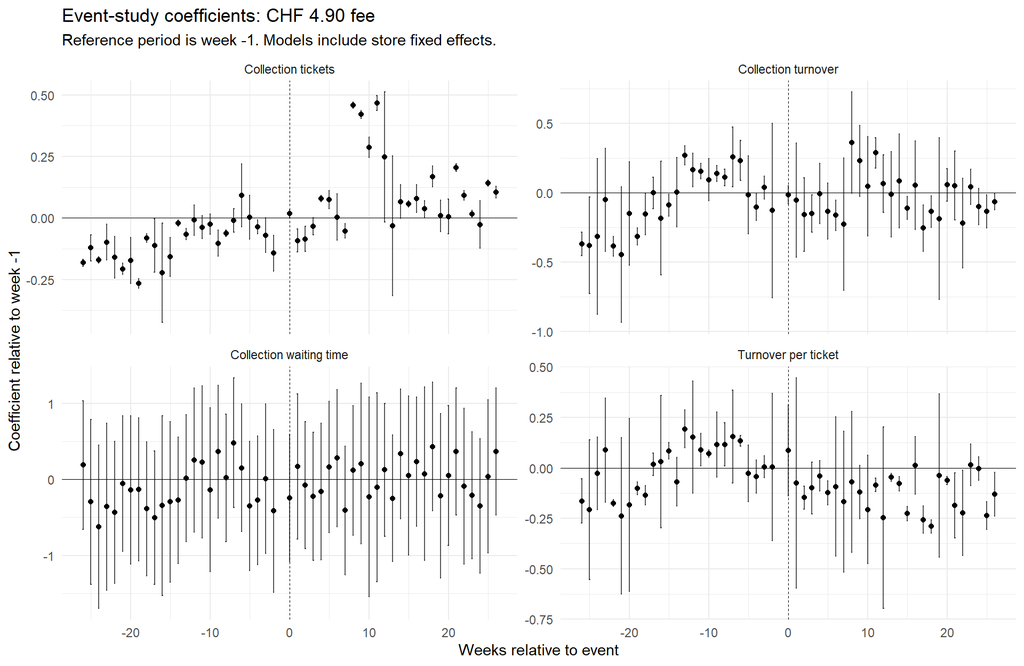

```r
plot_event_study_set(
  event_name = "CHF 4.90 fee",
  event_date = fee_date,
  outcomes = c("collection_turnover", "tickets_abholung", "avg_waiting_time_abholung", "throughput_proxy"),
  file_prefix = "fee"
)
```

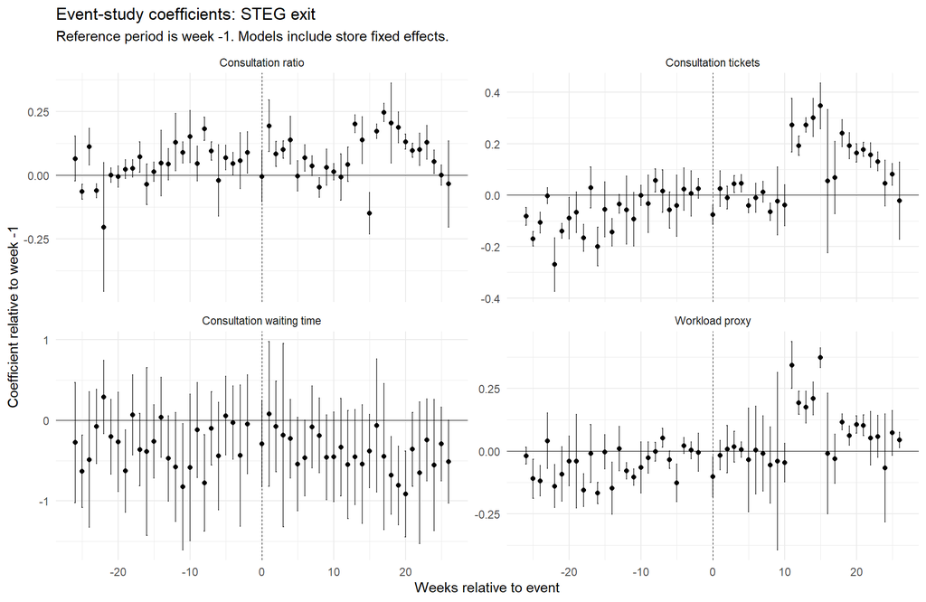

```r
plot_event_study_set(
  event_name = "STEG exit",
  event_date = steg_date,
  outcomes = c("tickets_beratung", "consultation_ratio", "avg_waiting_time_beratung", "workload_proxy"),
  file_prefix = "steg"
)
```

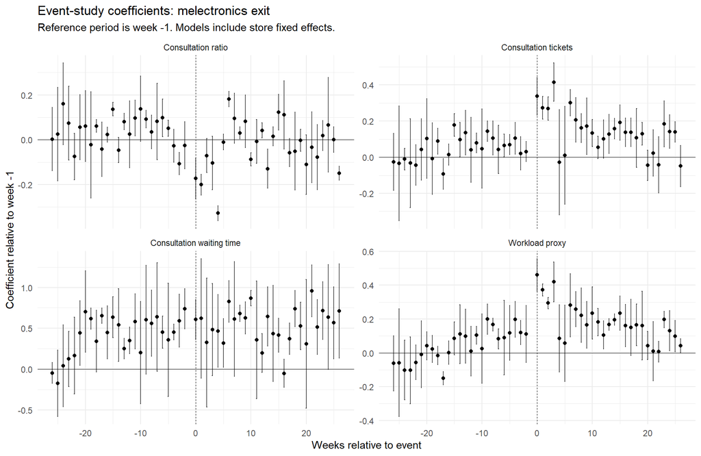

```r
plot_event_study_set(
  event_name = "melectronics exit",
  event_date = melectronics_date,
  outcomes = c("tickets_beratung", "consultation_ratio", "avg_waiting_time_beratung", "workload_proxy"),
  file_prefix = "melectronics"
)
```

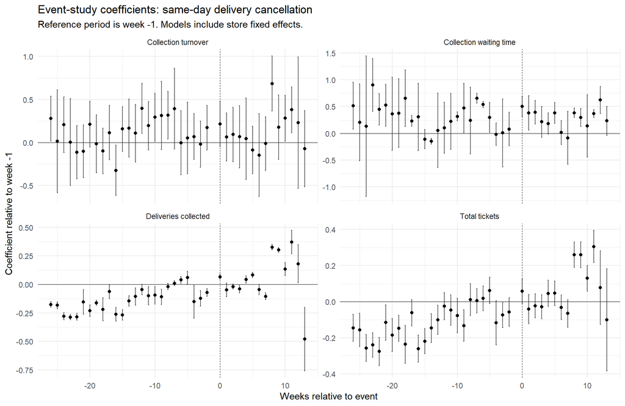

```r
plot_event_study_set(
  event_name = "same-day delivery cancellation",
  event_date = same_day_end_date,
  outcomes = c("collection_turnover", "deliveries_collected", "total_tickets", "avg_waiting_time_abholung"),
  file_prefix = "same_day"
)
```

# 9 Store Heterogeneity

```r
run_heterogeneity_model <- function(data, outcome, event_var, model_group, transform = "log") {
  y <- if (transform == "log") paste0("ln_", outcome) else if (transform == "log1p") paste0("ln1p_", outcome) else outcome
  if (!y %in% names(data)) {
    log_model_status(model_group, outcome, transform, "skipped", glue("Outcome {y} not found."))
    return(NULL)
  }
  if (!event_var %in% names(data)) {
    log_model_status(model_group, outcome, transform, "skipped", glue("Event variable {event_var} not found."))
    return(NULL)
  }
  if (all(is.na(data[[event_var]])) || n_distinct(data[[event_var]], na.rm = TRUE) <= 1) {
    log_model_status(model_group, outcome, transform, "skipped", glue("Event variable {event_var} has no usable variation."))
    return(NULL)
  }

  fml <- as.formula(glue("{y} ~ {event_var} * store | week_of_year_fe"))
  fit <- tryCatch(
    feols(fml, data = data, vcov = "hetero", notes = FALSE),
    error = function(e) e
  )
  if (inherits(fit, "error")) {
    log_model_status(model_group, outcome, transform, "error", fit$message)
    return(NULL)
  }
  log_model_status(model_group, outcome, transform, "estimated", "")
  fit
}

hetero_fee_outcomes <- available_vars(c("collection_turnover", "tickets_abholung", "avg_waiting_time_abholung", "throughput_proxy"), weekly_panel)
hetero_fee_models <- map(
  hetero_fee_outcomes,
  ~ run_heterogeneity_model(weekly_panel, .x, "fee_post", model_group = "Fee heterogeneity", transform = "log")
)
names(hetero_fee_models) <- hetero_fee_outcomes
hetero_fee_models <- compact(hetero_fee_models)

display_model_table(hetero_fee_models, "Store heterogeneity in the fee event")
```

Store heterogeneity in the fee event

|  | Collection turnover | Collection tickets | Collection waiting time | Turnover per ticket |
| --- | --- | --- | --- | --- |
| After CHF 4.90 fee | -0.077 | 0.406*** | 0.377*** | -0.333*** |
|  | (0.042) | (0.016) | (0.050) | (0.035) |
| Zurich store | 0.959*** | 1.214*** | 0.991*** | -0.155*** |
|  | (0.041) | (0.013) | (0.044) | (0.030) |
| Fee event x Zurich | -0.111 | -0.052* | 0.247** | -0.112* |
|  | (0.059) | (0.025) | (0.076) | (0.049) |
| Observations | 822 | 822 | 820 | 825 |
| R2 | 0.511 | 0.941 | 0.544 | 0.237 |
| Within R2 | 0.484 | 0.938 | 0.521 | 0.175 |

Heteroskedasticity-robust standard errors in parentheses.  
Weekly models include store and week-of-year fixed effects unless stated otherwise.  
Dependent variables are log-transformed unless the table states otherwise.  
Significance levels: *** p < 0.001, ** p < 0.01, * p < 0.05.

```r
save_model_table(hetero_fee_models, "fee_store_heterogeneity.html", "Fee Event: Store Heterogeneity")
```

```r
hetero_fee_models_level <- map(
  hetero_fee_outcomes,
  ~ run_heterogeneity_model(
    weekly_panel,
    .x,
    "fee_post",
    model_group = "Fee heterogeneity levels",
    transform = "level"
  )
)
names(hetero_fee_models_level) <- hetero_fee_outcomes
hetero_fee_models_level <- compact(hetero_fee_models_level)

display_model_table(
  hetero_fee_models_level,
  "Store heterogeneity in the fee event in levels",
  notes = level_table_notes
)
```

Store heterogeneity in the fee event in levels

|  | Collection turnover | Collection tickets | Collection waiting time | Turnover per ticket |
| --- | --- | --- | --- | --- |
| After CHF 4.90 fee | -3271.716** | 297.754*** | 0.429*** | -10.800*** |
|  | (1013.866) | (20.795) | (0.072) | (1.178) |
| Zurich store | 46369.362*** | 1496.597*** | 2.008*** | -3.956* |
|  | (1700.015) | (22.397) | (0.107) | (1.685) |
| Fee event x Zurich | -12363.693*** | 650.706*** | 1.522*** | -1.908 |
|  | (2366.344) | (59.823) | (0.239) | (2.107) |
| Observations | 836 | 825 | 822 | 825 |
| R2 | 0.569 | 0.901 | 0.483 | 0.122 |
| Within R2 | 0.553 | 0.894 | 0.465 | 0.051 |

Heteroskedasticity-robust standard errors in parentheses.  
Weekly models include store and week-of-year fixed effects unless stated otherwise.  
Dependent variables are estimated in levels.  
Significance levels: *** p < 0.001, ** p < 0.01, * p < 0.05.

```r
save_model_table(
  hetero_fee_models_level,
  "fee_store_heterogeneity_levels.html",
  "Fee Event: Store Heterogeneity in Levels",
  notes = level_table_notes
)
```

# 10 Monthly Productivity Analysis

The newly available productivity series is observed monthly for Dietikon and Zurich from 2018 to 2025. It is analysed separately from the weekly panel to avoid artificial interpolation. The April 2020 value is zero for both stores because the stores were closed during the COVID-19 restrictions. These zeros are valid observations and are retained in the main analysis. The preferred productivity specifications are therefore estimated in levels. Log specifications on positive months are reported only as robustness checks.

```r
require_file(productivity_file)

productivity_monthly <- read_csv(
  productivity_file,
  show_col_types = FALSE
) %>%
  clean_names() %>%
  mutate(
    month_start = as.Date(month_start),
    productivity = parse_numeric(as.character(productivity)),
    productivity_raw = parse_numeric(as.character(productivity_raw)),
    store = factor(store, levels = c("DT", "ZH")),
    year = year(month_start),
    month = month(month_start),
    month_of_year_fe = factor(month),
    period = case_when(
      year %in% c(2018, 2019) ~ "Pre-COVID",
      year %in% c(2020, 2021) ~ "COVID",
      year %in% c(2022, 2023) ~ "Post-COVID",
      year %in% c(2024, 2025) ~ "New Normal",
      TRUE ~ NA_character_
    ),
    period = factor(
      period,
      levels = c("Pre-COVID", "COVID", "Post-COVID", "New Normal")
    ),
    covid = as.integer(period == "COVID"),
    postcovid = as.integer(period == "Post-COVID"),
    newnormal = as.integer(period == "New Normal"),
    fee_post = as.integer(month_start >= floor_date(fee_date, "month")),
    steg_post = as.integer(month_start >= floor_date(steg_date, "month")),
    melectronics_post = as.integer(
      month_start >= floor_date(melectronics_date, "month")
    ),
    same_day_end_post = as.integer(
      month_start >= floor_date(same_day_end_date, "month")
    ),
    ln_productivity = if_else(productivity > 0, log(productivity), NA_real_)
  ) %>%
  filter(year >= 2018, year <= 2025)

productivity_quality <- make_data_quality_report(
  productivity_monthly,
  data_name = "productivity_monthly"
)
productivity_quality

write_csv(
  productivity_monthly,
  file.path(output_dir, "clean_data", "productivity_monthly_dt_zh.csv")
)
```

## 10.1 Descriptive Productivity Evidence

```r
productivity_period_averages <- productivity_monthly %>%
  group_by(store, period) %>%
  summarise(
    `Mean productivity` = mean(productivity, na.rm = TRUE),
    `Median productivity` = median(productivity, na.rm = TRUE),
    `Standard deviation` = sd(productivity, na.rm = TRUE),
    `Non-missing months` = sum(!is.na(productivity)),
    .groups = "drop"
  ) %>%
  mutate(Period = clean_period_label(period)) %>%
  rename(Store = store) %>%
  select(Store, Period, everything(), -period)

knitr::kable(
  productivity_period_averages,
  booktabs = TRUE,
  linesep = "",
  digits = 2,
  caption = "Descriptive monthly productivity averages by store"
)
```

Descriptive monthly productivity averages by store

| Store | Period | Mean productivity | Median productivity | Standard deviation | Non-missing months |
| --- | --- | --- | --- | --- | --- |
| DT | Pre COVID | 6.12 | 6.06 | 0.65 | 24 |
| DT | COVID | 5.69 | 5.77 | 1.44 | 24 |
| DT | Post COVID | 6.06 | 6.04 | 0.74 | 24 |
| DT | New Normal | 6.72 | 6.92 | 0.87 | 24 |
| ZH | Pre COVID | 8.22 | 8.14 | 0.55 | 24 |
| ZH | COVID | 6.97 | 7.19 | 1.67 | 24 |
| ZH | Post COVID | 7.24 | 7.12 | 0.71 | 24 |
| ZH | New Normal | 7.96 | 7.80 | 0.84 | 24 |

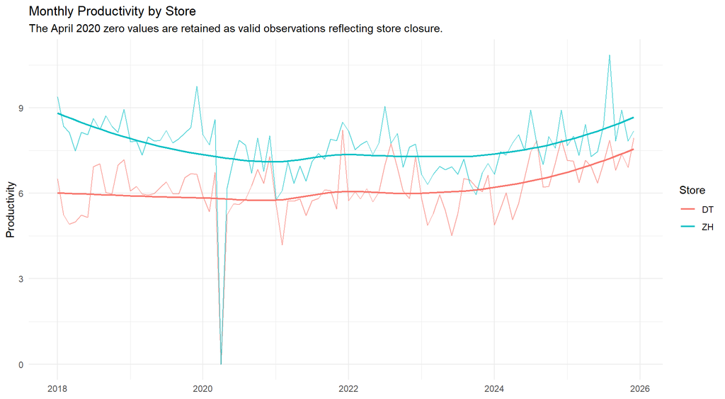

```r
save_df_table_png(
  productivity_period_averages,
  "tab_productivity_period_averages.png",
  title = "Descriptive monthly productivity averages by store",
  note = "April 2020 zero values are retained as valid observations reflecting COVID-19 store closure."
)

p_productivity <- ggplot(
  productivity_monthly,
  aes(x = month_start, y = productivity, colour = store)
) +
  geom_line(alpha = 0.65, na.rm = TRUE) +
  geom_smooth(se = FALSE, linewidth = 0.8, na.rm = TRUE) +
  labs(
    title = "Monthly Productivity by Store",
    subtitle = "The April 2020 zero values are retained as valid observations reflecting store closure.",
    x = NULL,
    y = "Productivity",
    colour = "Store"
  )

print(p_productivity)
```

```r
save_plot_png(
  p_productivity,
  "fig_monthly_productivity.png",
  width = 10,
  height = 5.5
)
```

## 10.2 Monthly Productivity Regressions

The main productivity regressions are estimated in levels so that the April 2020 closure observations remain in the sample. Log specifications on positive months are reported as robustness checks.

```r
productivity_level_notes <- c(
  "April 2020 zeros are retained as valid observations reflecting COVID-19 store closure.",
  "Heteroskedasticity-robust standard errors in parentheses.",
  "Models include store and month-of-year fixed effects unless stated otherwise.",
  significance_note
)

model_productivity_period_level <- run_fe_model(
  data = productivity_monthly,
  outcome = "productivity",
  rhs = "covid + postcovid + newnormal",
  model_group = "Monthly productivity",
  transform = "level",
  fixed_effects = "store + month_of_year_fe",
  min_n = 30
)

model_productivity_fee_level <- run_fe_model(
  data = productivity_monthly,
  outcome = "productivity",
  rhs = "fee_post",
  model_group = "Monthly productivity",
  transform = "level",
  fixed_effects = "store + month_of_year_fe",
  min_n = 30
)

model_productivity_competitors_level <- run_fe_model(
  data = productivity_monthly,
  outcome = "productivity",
  rhs = "steg_post + melectronics_post",
  model_group = "Monthly productivity",
  transform = "level",
  fixed_effects = "store + month_of_year_fe",
  min_n = 30
)

model_productivity_same_day_level <- run_fe_model(
  data = productivity_monthly,
  outcome = "productivity",
  rhs = "same_day_end_post",
  model_group = "Monthly productivity",
  transform = "level",
  fixed_effects = "store + month_of_year_fe",
  min_n = 30
)

productivity_level_models <- compact(list(
  "Period comparison" = model_productivity_period_level,
  "CHF 4.90 fee" = model_productivity_fee_level,
  "Competitor exits" = model_productivity_competitors_level,
  "Same-day cancellation" = model_productivity_same_day_level
))

display_model_table(
  productivity_level_models,
  "Monthly productivity models in levels",
  notes = productivity_level_notes
)
```

Monthly productivity models in levels

|  | Period comparison | CHF 4.90 fee | Competitor exits | Same-day cancellation |
| --- | --- | --- | --- | --- |
| COVID (2020--2021) | -0.837*** |  |  |  |
|  | (0.211) |  |  |  |
| Post-COVID (2022--2023) | -0.521*** |  |  |  |
|  | (0.142) |  |  |  |
| New Normal (2024--2025) | 0.174 |  |  |  |
|  | (0.139) |  |  |  |
| After CHF 4.90 fee |  | 0.806*** |  |  |
|  |  | (0.148) |  |  |
| After STEG exit |  |  | -0.013 |  |
|  |  |  | (0.170) |  |
| After melectronics exit |  |  | 0.858*** |  |
|  |  |  | (0.200) |  |
| After same-day delivery cancellation |  |  |  | 0.573** |
|  |  |  |  | (0.196) |
| Observations | 192 | 192 | 192 | 192 |
| R2 | 0.555 | 0.508 | 0.511 | 0.466 |
| Within R2 | 0.178 | 0.091 | 0.096 | 0.013 |

April 2020 zeros are retained as valid observations reflecting COVID-19 store closure.  
Heteroskedasticity-robust standard errors in parentheses.  
Models include store and month-of-year fixed effects unless stated otherwise.  
Significance levels: *** p < 0.001, ** p < 0.01, * p < 0.05.

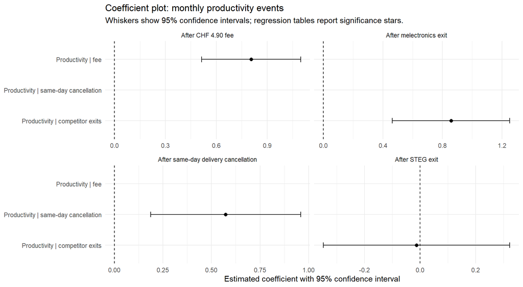

```r
save_model_table(
  productivity_level_models,
  "tab_productivity_models_levels.png",
  "Monthly productivity models in levels",
  notes = productivity_level_notes
)

plot_event_coefficients(
  compact(list(
    "Productivity | fee" = model_productivity_fee_level,
    "Productivity | competitor exits" = model_productivity_competitors_level,
    "Productivity | same-day cancellation" = model_productivity_same_day_level
  )),
  "Coefficient plot: monthly productivity events",
  "coefplot_productivity_events_levels.png"
)
```

```r
productivity_log_notes <- c(
  "The two April 2020 closure zeros cannot enter the logarithmic specification and are excluded only from this robustness model.",
  "Heteroskedasticity-robust standard errors in parentheses.",
  "Models include store and month-of-year fixed effects unless stated otherwise.",
  "The dependent variable is log productivity.",
  significance_note
)

model_productivity_period_log <- run_fe_model(
  data = productivity_monthly,
  outcome = "productivity",
  rhs = "covid + postcovid + newnormal",
  model_group = "Monthly productivity",
  transform = "log",
  fixed_effects = "store + month_of_year_fe",
  min_n = 30
)

model_productivity_fee_log <- run_fe_model(
  data = productivity_monthly,
  outcome = "productivity",
  rhs = "fee_post",
  model_group = "Monthly productivity",
  transform = "log",
  fixed_effects = "store + month_of_year_fe",
  min_n = 30
)

model_productivity_competitors_log <- run_fe_model(
  data = productivity_monthly,
  outcome = "productivity",
  rhs = "steg_post + melectronics_post",
  model_group = "Monthly productivity",
  transform = "log",
  fixed_effects = "store + month_of_year_fe",
  min_n = 30
)

model_productivity_same_day_log <- run_fe_model(
  data = productivity_monthly,
  outcome = "productivity",
  rhs = "same_day_end_post",
  model_group = "Monthly productivity",
  transform = "log",
  fixed_effects = "store + month_of_year_fe",
  min_n = 30
)

productivity_log_models <- compact(list(
  "Period comparison" = model_productivity_period_log,
  "CHF 4.90 fee" = model_productivity_fee_log,
  "Competitor exits" = model_productivity_competitors_log,
  "Same-day cancellation" = model_productivity_same_day_log
))

display_model_table(
  productivity_log_models,
  "Monthly productivity models: log-positive robustness",
  notes = productivity_log_notes
)
```

Monthly productivity models: log-positive robustness

|  | Period comparison | CHF 4.90 fee | Competitor exits | Same-day cancellation |
| --- | --- | --- | --- | --- |
| COVID (2020--2021) | -0.081*** |  |  |  |
|  | (0.019) |  |  |  |
| Post-COVID (2022--2023) | -0.071*** |  |  |  |
|  | (0.020) |  |  |  |
| New Normal (2024--2025) | 0.028 |  |  |  |
|  | (0.019) |  |  |  |
| After CHF 4.90 fee |  | 0.108*** |  |  |
|  |  | (0.017) |  |  |
| After STEG exit |  |  | -0.012 |  |
|  |  |  | (0.023) |  |
| After melectronics exit |  |  | 0.123*** |  |
|  |  |  | (0.026) |  |
| After same-day delivery cancellation |  |  |  | 0.082** |
|  |  |  |  | (0.028) |
| Observations | 190 | 190 | 190 | 190 |
| R2 | 0.662 | 0.638 | 0.642 | 0.589 |
| Within R2 | 0.195 | 0.139 | 0.147 | 0.023 |

The two April 2020 closure zeros cannot enter the logarithmic specification and are excluded only from this robustness model.  
Heteroskedasticity-robust standard errors in parentheses.  
Models include store and month-of-year fixed effects unless stated otherwise.  
The dependent variable is log productivity.  
Significance levels: *** p < 0.001, ** p < 0.01, * p < 0.05.

```r
save_model_table(
  productivity_log_models,
  "tab_productivity_models_log_robustness.png",
  "Monthly productivity models: log-positive robustness",
  notes = productivity_log_notes
)
```

## 10.3 Productivity Store Heterogeneity

```r
model_productivity_fee_heterogeneity <- tryCatch(
  feols(
    productivity ~ fee_post * store | month_of_year_fe,
    data = productivity_monthly,
    vcov = "hetero",
    notes = FALSE
  ),
  error = function(e) NULL
)

if (!is.null(model_productivity_fee_heterogeneity)) {
  display_model_table(
    list("Monthly productivity" = model_productivity_fee_heterogeneity),
    "Monthly productivity: fee-event store heterogeneity",
    notes = c(
      "Heteroskedasticity-robust standard errors in parentheses.",
      "The model includes month-of-year fixed effects.",
      "The dependent variable is monthly productivity in levels.",
      significance_note
    )
  )

  save_model_table(
    list("Monthly productivity" = model_productivity_fee_heterogeneity),
    "tab_productivity_fee_heterogeneity_levels.png",
    "Monthly productivity: fee-event store heterogeneity",
    notes = c(
      "Heteroskedasticity-robust standard errors in parentheses.",
      "The model includes month-of-year fixed effects.",
      "The dependent variable is monthly productivity in levels.",
      significance_note
    )
  )
}
```

# 11 Monthly NPS Analysis

```r
read_nps_store <- function(path, store_code) {
  require_file(path)
  raw <- read_tsv(path, locale = locale(encoding = "UTF-16LE"), show_col_types = FALSE) %>%
    clean_names()

  # The export uses long German column names, so positions are more stable here.
  col_month <- names(raw)[1]
  col_class <- names(raw)[2]
  col_nps_decimal <- names(raw)[4]
  col_weight <- names(raw)[5]
  col_share <- names(raw)[6]

  raw %>%
    transmute(
      store = store_code,
      month_start = parse_nps_month(.data[[col_month]]),
      ppd_classification = as.character(.data[[col_class]]),
      nps_decimal = parse_numeric(.data[[col_nps_decimal]]),
      nps_score = nps_decimal * 100,
      nps_weight = parse_numeric(.data[[col_weight]]),
      response_share = parse_numeric(.data[[col_share]]) / 100
    ) %>%
    filter(!is.na(month_start))
}

nps_long <- bind_rows(
  read_nps_store(nps_file_dt, "DT"),
  read_nps_store(nps_file_zh, "ZH")
) %>%
  filter(month_start >= floor_date(analysis_start, "month"),
         month_start <= floor_date(analysis_end, "month"))

nps_monthly <- nps_long %>%
  group_by(store, month_start) %>%
  summarise(
    nps_decimal = mean(nps_decimal, na.rm = TRUE),
    nps_score = mean(nps_score, na.rm = TRUE),
    detractor_share = sum(response_share[ppd_classification == "Detractor"], na.rm = TRUE),
    passive_share = sum(response_share[ppd_classification == "Passive"], na.rm = TRUE),
    promoter_share = sum(response_share[ppd_classification == "Promoter"], na.rm = TRUE),
    .groups = "drop"
  ) %>%
  mutate(
    store = factor(store, levels = c("DT", "ZH")),
    year = year(month_start),
    month = month(month_start),
    month_of_year_fe = factor(month),
    fee_post = make_post_dummy(month_start, floor_date(fee_date, "month")),
    steg_post = make_post_dummy(month_start, floor_date(steg_date, "month")),
    melectronics_post = make_post_dummy(month_start, floor_date(melectronics_date, "month")),
    same_day_end_post = make_post_dummy(month_start, floor_date(same_day_end_date, "month"))
  )

nps_quality <- make_data_quality_report(nps_monthly, data_name = "nps_monthly")
nps_quality

write_csv(nps_long, file.path(output_dir, "clean_data", "nps_long_dt_zh.csv"))
write_csv(nps_monthly, file.path(output_dir, "clean_data", "nps_monthly_dt_zh.csv"))
```

```r
monthly_ops <- weekly_panel %>%
  group_by(store, month_start) %>%
  summarise(
    total_turnover = sum(total_turnover, na.rm = TRUE),
    collection_turnover = sum(collection_turnover, na.rm = TRUE),
    turnover_collected = sum(turnover_collected, na.rm = TRUE),
    deliveries_collected = sum(deliveries_collected, na.rm = TRUE),
    total_tickets = sum(total_tickets, na.rm = TRUE),
    tickets_abholung = sum(tickets_abholung, na.rm = TRUE),
    tickets_beratung = sum(tickets_beratung, na.rm = TRUE),
    avg_waiting_time_abholung = mean(avg_waiting_time_abholung, na.rm = TRUE),
    avg_waiting_time_beratung = mean(avg_waiting_time_beratung, na.rm = TRUE),
    avg_duration_abholung = mean(avg_duration_abholung, na.rm = TRUE),
    avg_duration_beratung = mean(avg_duration_beratung, na.rm = TRUE),
    throughput_proxy = mean(throughput_proxy, na.rm = TRUE),
    consultation_share = if_else(total_tickets > 0, tickets_beratung / total_tickets, NA_real_),
    workload_proxy = sum(workload_proxy, na.rm = TRUE),
    .groups = "drop"
  ) %>%
  add_log_variables()

nps_panel <- nps_monthly %>%
  left_join(monthly_ops, by = c("store", "month_start")) %>%
  mutate(
    time_index = as.integer(interval(min(month_start, na.rm = TRUE), month_start) %/% months(1))
  )

nps_panel_quality <- make_data_quality_report(nps_panel, data_name = "nps_panel")
nps_panel_quality

write_csv(nps_panel, file.path(output_dir, "clean_data", "nps_monthly_panel_dt_zh.csv"))
```

```r
nps_models <- list()

nps_models[["NPS | same-day cancellation"]] <- run_fe_model(
  data = nps_panel,
  outcome = "nps_score",
  rhs = "same_day_end_post",
  model_group = "NPS",
  transform = "level",
  fixed_effects = "store + month_of_year_fe",
  min_n = 10
)

nps_models[["NPS | operational pressure"]] <- run_fe_model(
  data = nps_panel,
  outcome = "nps_score",
  rhs = "ln_total_tickets + ln_avg_waiting_time_beratung + consultation_share",
  model_group = "NPS",
  transform = "level",
  fixed_effects = "store + month_of_year_fe",
  min_n = 10
)

nps_models <- compact(nps_models)

display_model_table(nps_models, "Supplementary monthly NPS models")
```

Supplementary monthly NPS models

|  | NPS \| same-day cancellation | NPS \| operational pressure |
| --- | --- | --- |
| After same-day delivery cancellation | -0.741 |  |
|  | (1.592) |  |
| Log total tickets |  | -2.007 |
|  |  | (3.572) |
| Log consultation waiting time |  | -1.870 |
|  |  | (1.750) |
| Consultation share |  | -5.631 |
|  |  | (27.853) |
| Observations | 80 | 80 |
| R2 | 0.286 | 0.307 |
| Within R2 | 0.003 | 0.032 |

Heteroskedasticity-robust standard errors in parentheses.  
Weekly models include store and week-of-year fixed effects unless stated otherwise.  
Dependent variables are log-transformed unless the table states otherwise.  
Significance levels: *** p < 0.001, ** p < 0.01, * p < 0.05.

```r
save_model_table(nps_models, "nps_supplementary_models.html", "Supplementary Monthly NPS Models")
```

# 12 AI-Supported Workload Simulation

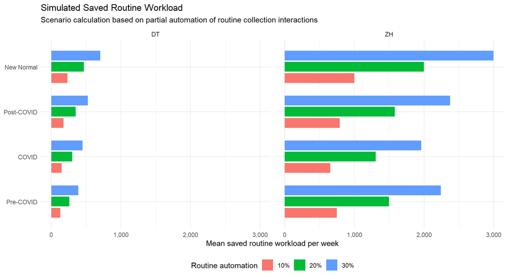

```r
automation_rates <- tibble(automation_rate = c(0.10, 0.20, 0.30))

workload_simulation <- weekly_panel %>%
  select(store, week_start, period, tickets_abholung, tickets_beratung,
         avg_duration_abholung, avg_duration_beratung, workload_proxy) %>%
  crossing(automation_rates) %>%
  mutate(
    saved_time = automation_rate * tickets_abholung * avg_duration_abholung,
    remaining_workload = workload_proxy - saved_time,
    workload_reduction_share = if_else(workload_proxy > 0, saved_time / workload_proxy, NA_real_)
  )

workload_summary <- workload_simulation %>%
  group_by(store, period, automation_rate) %>%
  summarise(
    mean_workload = mean(workload_proxy, na.rm = TRUE),
    mean_saved_time = mean(saved_time, na.rm = TRUE),
    mean_remaining_workload = mean(remaining_workload, na.rm = TRUE),
    mean_reduction_share = mean(workload_reduction_share, na.rm = TRUE),
    n_weeks = n(),
    .groups = "drop"
  )

workload_summary
write_csv(workload_summary, file.path(output_dir, "tables", "workload_simulation_summary.csv"))
save_df_table_png(
  workload_summary,
  "tab_workload_simulation_summary.png",
  title = "AI-supported workload simulation summary",
  note = "Scenario calculation based on partial automation of routine collection interactions."
)

workload_summary <- workload_summary %>%
  mutate(
    period_label = factor(
      period,
      levels = c("Pre-COVID", "COVID", "Post-COVID", "New Normal"),
      labels = c("Pre-COVID", "COVID", "Post-COVID", "New Normal")
    ),
    automation_label = factor(
      automation_rate,
      levels = c(0.10, 0.20, 0.30),
      labels = c("10%", "20%", "30%")
    )
  )

p_workload <- ggplot(workload_summary, aes(x = mean_saved_time, y = period_label, fill = automation_label)) +
  geom_col(position = position_dodge(width = 0.75), width = 0.65) +
  facet_wrap(~ store) +
  scale_x_continuous(labels = comma) +
  labs(
    title = "Simulated Saved Routine Workload",
    subtitle = "Scenario calculation based on partial automation of routine collection interactions",
    x = "Mean saved routine workload per week",
    y = NULL,
    fill = "Routine automation"
  ) +
  theme(
    legend.position = "bottom"
  )

print(p_workload)
```

```r
ggsave(file.path(output_dir, "figures", "workload_simulation.png"), p_workload, width = 9, height = 5, bg = "white")
save_plot_png(p_workload, "workload_simulation.png", width = 9, height = 5)
```

# 13 Exported Appendix PNG Files

All thesis-relevant figures and tables are exported as PNG files. The files for direct appendix upload are saved in `output/appendix_png`. Regression tables include a note explaining the significance stars: `*** p < 0.001`, `** p < 0.01`, `* p < 0.05`. Table PNGs are rendered directly with grid/gridExtra and do not require Chrome, webshot2, or PhantomJS.

```r
variable_availability <- tibble(
  variable = sort(names(weekly_panel)),
  type = map_chr(weekly_panel, ~ class(.x)[1]),
  n_missing = map_int(weekly_panel, ~ sum(is.na(.x))),
  n_distinct = map_int(weekly_panel, ~ n_distinct(.x, na.rm = TRUE))
)

write_csv(variable_availability, file.path(output_dir, "diagnostics", "variable_availability_weekly_panel.csv"))
write_csv(model_log, file.path(output_dir, "diagnostics", "model_log.csv"))

appendix_png_inventory <- tibble(
  file = list.files(file.path(output_dir, "appendix_png"), pattern = "\\.png$", full.names = FALSE),
  path = file.path(output_dir, "appendix_png", file)
)
write_csv(appendix_png_inventory, file.path(output_dir, "diagnostics", "appendix_png_inventory.csv"))

model_log
```